# Kostenoffenlegung als Wettbewerbsvorteil

Chancen und Potenziale der Kostentransparenz

# Motivation

Die Untersuchung von Kostentransparenz ist aus ökonomischer Sicht besonders spannend, da sie Einblicke in das Zusammenspiel von Marktverhalten, Preiswahrnehmung und Konsumentenvertrauen ermöglicht. In klassischen Märkten gilt Information als asymmetrisch verteilt - insbesondere Kostenstrukturen bleiben für Konsument:innen meist verborgen. Wenn Unternehmen jedoch freiwillig ihre Produktionskosten offenlegen, entsteht eine neue Form der Marktkommunikation, die sowohl auf das Kaufverhalten als auch auf die Markenbindung Einfluss nehmen kann.

In diesem Projekt beschäftigen Sie sich mit der ökonomischen Wirkung unterschiedlicher Formen von Kostentransparenz, darunter produktbezogene Einzelkosten-Offenlegung im Point-of-Sale oder auch verbal vermittelte Transparenz in Kombination mit Vertrauensmessung. Ziel ist es, zu untersuchen, wie sich diese Varianten auf Zahlungsbereitschaft, Vertrauen und wahrgenommene Preisfairness auswirken.

Kern dieser Ausarbeitung ist die Frage, inwiefern Kostentransparenz eine rationale Kaufentscheidung unterstützt oder über emotionale Mechanismen - etwa durch erhöhte Markenattraktivität - wirkt. Für die Analyse greifen Sie auf ein breites Methodenrepertoire zurück, das ökonomische Modellierung mit experimenteller Verhaltensforschung verbindet, und leisten so einen Beitrag zum besseren Verständnis moderner Konsumentenentscheidungen in transparenten Märkten. Für ihre Analyse verwenden Sie die Daten der folgenden Ausarbeitung:

**Mohan, B., Buell, R. W., & John, L. K. (2020). Lifting the veil: The benefits of cost transparency. Marketing Science, 39(6), 1105-1121.**

# Aufbau der Studie

1. Lesen Sie sich den folgenden Text zum Hintergrund und Aufbau der Studie durch und beantworten Sie nachfolgende Fragen dazu:

Der Ausgangspunkt der betrachteten Untersuchung war ein reales Ereignis: Ein Online-Händler stellte im Dezember 2013 ein hochwertiges Lederportemonnaie zum Verkauf. Einige Wochen später wurde auf den Produktseiten eine Infografik zur Kostenzusammensetzung ergänzt, allerdings versehentlich nur bei drei von fünf Farbvarianten. Obwohl der Händler diesen Fehler nicht beabsichtigte, entstand daraus ein sogenanntes natürliches Experiment, also eine reale Vergleichssituation mit kontrollierbaren Unterschieden. Die Verkäufe konnten analysiert werden, um zu überprüfen, ob die Offenlegung der Produktionskosten einen Einfluss auf das Kaufverhalten hatte.

Dieses natürliche Experiment lieferte erste Hinweise darauf, dass Kostentransparenz wirkt - und war damit die Basis für zwei gezielte Experimente im Labor, die Sie sich in diesem Projekt genauer anschauen sollen. Beide Laborexperimente knüpfen an die reale Ausgangslage an - gehen aber unterschiedliche Forschungsfragen an:

Experiment 1: In einem realitätsnahen Online-Setting wurde untersucht, ob Konsument:innen anders entscheiden, wenn sie Informationen zu Produktionskosten sehen. Hierbei sahen die Teilnehmer:innen eine Produktseite für einen Rucksack von Everlane - entweder mit oder ohne Kostenaufstellung (vgl. Abbildung 1: Kostentransparenz Infografik im Anhang). Zusätzlich wurde ein Vergleichsprodukt von J. Crew gezeigt (ohne Hinweise zur Kostenzusammensetzung). Die Teilnehmer:innen mussten entscheiden, von welchem Anbieter sie lieber einen Gutschein erhalten würden. Das Ziel der Forscher war es zu messen, ob Konsument:innen bei mehr Transparenz auch eher kaufen, folglich sich für diesen Gutschein entscheiden.

Experiment 2: Nachdem Experiment 1 zeigte, dass es einen Effekt der Kostentransparenz gibt, stellt sich die psychologische Anschlussfrage, warum es diesen Effekt gibt und wie dieser festzumachen ist. So sahen die Teilnehmer:innen im 2. Experiment ein fiktives Produkt - eine Schokoladentafel. In der Kontrollgruppe wurden nur übliche Produktinfos gezeigt. In der Treatmentgruppe gab es zusätzlich eine detaillierte Kostenaufstellung (vgl. Abbildung 2: Design der Schokoladenverpackung ohne und mit Kostentransparenz im Anhang). Im Anschluss wurden Vertrauen in die Marke und Kaufbereitschaft durch einen Fragebogen abgefragt. So sollte herausgefunden werden, ob Vertrauen der zentrale psychologische Mechanismus für die Kaufentscheidung der Kund:innen ist.

Beantworten Sie nun folgende Fragen:

1. Welches reale Ereignis war der Auslöser der Forschung?
2. Welche konkrete Verhaltensfrage steht im Mittelpunkt von Experiment 1 - Was wollten die Forscher:innen direkt am Kaufverhalten testen?
3. Welcher psychologische Faktor steht im Zentrum von Experiment 2 - und wie hängt er mit dem Kaufverhalten zusammen?

**Welches reale Ereignis war der Auslöser der Forschung?** Auslöser der Forschung war ein unbeabsichtigtes natürliches Experiment bei einem Online-Händler im Dezember 2013: Dieser ergänzte bei einem hochwertigen Lederportemonnaie eine Infografik zur Kostenstruktur – allerdings versehentlich nur bei drei von fünf Farbvarianten. Durch diese reale Vergleichssituation war es den Forschern möglich, zu analysieren, ob die Offenlegung der Produktionskosten einen direkten Einfluss auf die Verkaufszahlen hatte.

**Welche konkrete Verhaltensfrage steht im Mittelpunkt von Experiment 1 - Was wollten die Forscher:innen direkt am Kaufverhalten testen?** Im Mittelpunkt von Experiment 1 stand die Frage, ob Konsumenten bei Kostentransparenz eine andere Kaufentscheidung treffen würden. Konkret wollten die Forscher testen, ob die Anzeige einer Kostenaufstellung die Kaufpräferenz der Konsumenten erhöht. Dies wurde gemessen, indem die Teilnehmer entscheiden mussten, ob sie lieber einen Gutschein für das transparente Unternehmen Everlane oder für das Vergleichsunternehmen J. Crew ohne Kostentransparenz erhalten würden. Eine Entscheidung für den Everlane-Gutschein wurde als Indikator für eine höhere Kaufabsicht interpretiert.

**Welcher psychologische Faktor steht im Zentrum von Experiment 2 - und wie hängt er mit dem Kaufverhalten zusammen?** Im Zentrum von Experiment 2 steht der psychologische Faktor Vertrauen. Nachdem in Experiment 1 gezeigt wurde, dass Kostentransparenz wirkt, sollte in Experiment 2 geklärt werden, warum dies der Fall ist. Die Forscher stellten die Hypothese auf, dass die Offenlegung von Kosten das Vertrauen der Konsumenten in die Marke stärkt. Dieses erhöhte Vertrauen führt wiederum, so die Annahme, zu einer höheren Kaufbereitschaft. Der Zusammenhang besteht also darin, dass Vertrauen als zentraler psychologischer Mechanismus vermutet wird, der die positive Wirkung von Kostentransparenz auf die Kaufentscheidung erklärt.

Nachdem Sie nun die grundlegende Forschungsidee und Zielsetzung der beiden Experimente kennengelernt haben, befassen wir uns im nächsten Schritt vertiefend mit Experiment 1. Ziel ist es, den genauen Aufbau, sowie das konkrete Verhalten der Teilnehmer:innen besser zu verstehen.

2. Lesen Sie sich den folgenden Text zum Aufbau des ersten Experiments durch und beantworten Sie anschließend Fragen dazu:

Cost transparency refers to the disclosure of the costs to produce a good or provide a service. Although cost transparency is a strategy traditionally employed in the context of supplier-firm relationships, wherein the two-way sharing of cost information between parties facilitates collaboration on cost reduction measures, we investigate its effects within the context of consumer-firm relationships. Information on the costs associated with providing goods and services is rarely shared with consumers, but we provide evidence of when and why voluntarily doing so can increase consumers’ purchase interest. Specifically, building on the psychology of disclosure and trust, we posit that cost transparency, insofar as it represents an act of intimate disclosure, fosters trust. In turn, we propose that this heightened trust increases consumers’ willingness to purchase from the transparent firm. In the sections that follow, we discuss our central predictions and highlight alternative accounts. Then, we present experiments, conducted in the lab and in the field, that document the main effects of cost transparency, its underlying psychological drivers, and conditions that moderate its effects.

This first experiment explores how cost transparency influences consumer preferences in an online shopping context. The study was designed as a between-subjects randomized experiment using an incentive-compatible setup, meaning participants made real choices with the possibility of receiving a tangible reward. A total of 509 U.S.-based participants were recruited through Amazon Mechanical Turk (MTurk). Each participant was randomly assigned to one of two experimental conditions:

- Cost Transparency Condition: Participants were shown a simulated product page for a backpack sold by the retailer Everlane. This page included a cost breakdown infographic, listing the production costs such as materials, labor, transport, and duties, with a clearly stated total cost.
- Control Condition: Participants saw the same backpack from Everlane but without any cost information. In both conditions, participants also saw a comparable backpack from J. Crew, which does not practice cost transparency.

Participants were instructed to view both product pages and then asked which company they would prefer to receive a $50 gift card from. Their response served as the main behavioral outcome, representing a choice between the transparent vs. non-transparent retailer. To ensure accurate interpretation of the presented information, a comprehension check followed the main choice question. Participants were also asked for demographic information such as age, gender, income, and education, to allow for potential control variables in later analysis.

Beantworten Sie nun folgende Fragen:

1. Wie viele Personen nahmen final an dem Experiment teil?
2. Worin bestand der Unterschied zwischen der Transparenzbedingung und der Kontrollbedingung?
3. Welche Anreizstruktur wurde verwendet, um die Entscheidung der Teilnehmenden realistisch zu gestalten?
4. Wie unterschieden sich die beiden gezeigten Onlinehändler im Experiment?
5. Warum wurde im Anschluss an die Entscheidungsfrage ein Verständnischeck durchgeführt?
6. In der Beschreibung des Experiments wird von “between-subjects randomized experiment using an incentive-compatible setup” gesprochen. Was versteht man hierunter im Detail?

*Hinweis:* Für die Beantwortung der letzten Frage können Sie [diesen Artikel (Seite 1-5)](https://www.researchgate.net/publication/268269783_Incentives_in_Experiments_A_Theoretical_Analysis) als Grundlage verwenden.

**Wie viele Personen nahmen final an dem Experiment teil?** Insgesamt nahmen 509 in den USA ansässige Personen an dem Experiment teil, die über die Plattform Amazon Mechanical Turk (MTurk) rekrutiert wurden.

**Worin bestand der Unterschied zwischen der Transparenzbedingung und der Kontrollbedingung?** Der Unterschied lag in den Informationen, die auf der Produktseite des Everlane-Rucksacks gezeigt wurden:

-In der Transparenzbedingung (Cost Transparency Condition) enthielt die Produktseite eine Infografik, die die Kosten für Materialien, Arbeit, Transport und Zölle detailliert aufschlüsselte.

-In der Kontrollbedingung (Control Condition) sahen die Teilnehmenden dieselbe Produktseite, jedoch ohne diese Kostenaufstellung.

**Welche Anreizstruktur wurde verwendet, um die Entscheidung der Teilnehmenden realistisch zu gestalten?** Es wurde eine sogenannte anreizkompatible Struktur (Incentive-Compatible Setup) verwendet. Den Teilnehmenden wurde in Aussicht gestellt, dass sie einen Geschenkgutschein im Wert von 50 $ von dem Unternehmen erhalten, das sie in ihrer Antwort bevorzugen, tatsächlich. Dieser Anreiz motiviert die Teilnehmenden, ihre tatsächliche Präferenz anzugeben, da ihre Entscheidung reale Konsequenzen haben kann.

**Wie unterschieden sich die beiden gezeigten Onlinehändler im Experiment?** Die beiden Händler unterschieden sich in ihrer (im Experiment dargestellten) Strategie zur Kostentransparenz:

-Everlane wurde als das Unternehmen präsentiert, das (in der Transparenzbedingung) seine Kosten offenlegt.

-J. Crew diente als Vergleichsunternehmen, das bekanntermaßen keine Kostentransparenz praktiziert. Dessen Produktseite enthielt in beiden Versuchsgruppen keine Kosteninformationen.

**Warum wurde im Anschluss an die Entscheidungsfrage ein Verständnischeck durchgeführt?** Um sicherzustellen, dass die Teilnehmenden die präsentierten Informationen – insbesondere die Kostenaufstellung in der Transparenzgruppe – korrekt verstanden und interpretiert hatten, wurde ein Verständnischeck (comprehension check) durchgeführt. So soll ausgeschlossen werden, dass die Ergebnisse durch Missverständnisse verzerrt werden.

**In der Beschreibung des Experiments wird von “between-subjects randomized experiment using an incentive-compatible setup” gesprochen. Was versteht man hierunter im Detail?** Dieser Begriff beschreibt drei zentrale methodische Merkmale des Experiments:

1. **Between-subjects experiment** (Zwischensubjekt-Design): Jede Versuchsperson wird nur einer der beiden experimentellen Bedingungen (entweder Transparenz- oder Kontrollbedingung) zugewiesen. Der Effekt der Kostentransparenz wird dann gemessen, indem man die Ergebnisse der einen Gruppe mit den Ergebnissen der anderen Gruppe vergleicht. Der Vorteil ist, dass die Entscheidung der einen Gruppe nicht durch das Wissen über die andere Bedingung beeinflusst werden kann.
2. **Randomized experiment** (Randomisiertes Experiment): Die Zuweisung der Teilnehmenden zu den beiden Gruppen erfolgte zufällig. Diese Randomisierung ist entscheidend, um sicherzustellen, dass sich die Gruppen zu Beginn nicht systematisch unterscheiden (z.B. in Bezug auf Alter, Einkommen oder Markenpräferenzen). Eventuelle Unterschiede im Ergebnis können so mit größerer Sicherheit auf die experimentelle Manipulation (das Zeigen bzw. Nicht-Zeigen der Kosten) zurückgeführt werden.
3. **Incentive-compatible setup** (Anreizkompatibler Aufbau): Dies beschreibt die Anreizstruktur, die sicherstellen soll, dass Teilnehmende ihre wahren Präferenzen offenlegen. Ein Aufbau ist anreizkompatibel, wenn die beste Strategie für einen rational handelnden Teilnehmenden darin besteht, ehrlich zu antworten. Im konkreten Fall maximiert ein Teilnehmer seine Chance auf eine für ihn wertvolle Belohnung (einen 50 $-Gutschein), wenn er das Unternehmen wählt, bei dem er tatsächlich lieber einkaufen würde. Dies macht die erhobenen Daten über die Kaufpräferenz deutlich aussagekräftiger als eine rein hypothetische Abfrage.

# Daten

## Datenimport und -aufbereitung

Die Daten, die Sie für die nachfolgenden Analysen verwenden, wurden zu Replikationszwecken von den Autoren der Studie zur Verfügung gestellt und können hier heruntergeladen werden:

**Bhavya Mohan, Ryan W. Buell, Leslie K. John (2020) Lifting the Veil: The Benefits of Cost Transparency. Marketing Science 39(6):1105-1121. mksc.2019.1200.sm1.pdf**

Wir haben die Daten für Sie heruntergeladen und im Unterordner mit dem Namen `Daten` bereitgestellt. Für ihre Analyse werden die Dateien `Experiment1.csv` und `Experiment2.csv` genutzt. Für die Zusatzaufgabe ist die Datei `Experiment3.csv` relevant.

3. Lesen Sie den Datensatz `Experiment1.csv` aus dem Unterordner `Daten` in R ein. Nennen Sie den Datensatz in R `daten_exp1`.

Im Datensatz sind unterschiedliche Variablen enthalten. Weiterhin habe wir Ihnen ein Readme mit den Beschreibungen zu den Variablen bereitgestellt. Nutzen Sie dieses und den Text aus Aufgabe 2, um die Variablen zu beschreiben.

Dieser Datensatz umfasst acht Variablen, diese sind:

**treatment:** Gibt an, ob die Teilnehmer die kostentransparente Website gesehen haben (1 = Kosten-Transparenz, 0 = Kontrolle);Unabhängige Variable zur Messung des Effekts von Kostentransparenz

**everlane:** Gibt die Wahl der Geschenkkarte an (1 = Wahl der Everlane-Geschenkkarte, 0 = Wahl der J Crew-Geschenkkarte);Abhängige Variable: misst tatsächliche Präferenz bzw. Wahlverhalten

**passed:** Gibt an, ob die Teilnehmer den Verständnis-Test bestanden haben (1 = Test bestanden, 0 = Test nicht bestanden);Qualitätskontrolle: Sicherung der Datenvalidität durch Filterung unaufmerksamer Teilnehmer

**email_provided:** Gibt an, ob die Teilnehmer eine E-Mail-Adresse angegeben haben, an die die Geschenkkarte gesendet werden kann (1 = E-Mail-Adresse angegeben, 0 = Keine E-Mail-Adresse angegeben);Proxy für ernsthafte Teilnahmebereitschaft bzw. Engagement

**female:** Teilnehmer haben optional ihr Geschlecht angegeben (1 = weiblich, 0 = männlich);Demografische Kontrollvariable (Geschlechtsunterschiede in Wahrnehmung & Vertrauen)

**age:** Teilnehmer haben optional ihr Alter angegeben (offene Antwort);Kontrollvariable – mögliche Altersunterschiede in Reaktionen auf Transparenz

**educ:** Teilnehmer haben optional ihren Bildungsabschluss angegeben (1 = Einige Jahre in der Schule, 2 = Schulabschluss, 3 = Einige Jahre College, 4 = Hochschulabschluss, 5 = Postgradual/beruflich);Kontrollvariable – untersucht Bildungseinfluss auf Vertrauen, Rationalität etc

**income:** Teilnehmer haben optional ihr monatliches Einkommensniveau angegeben (1 = Keines, 2 = Unter 60 Dollar, 3 = 60-499 Dollar, 4 = 500-999 Dollar, 5 = 1.000-1.999 Dollar, 6 = 2.000-2.999 Dollar, 7 = 3.000-3.999 Dollar, 8 = 4.000-4.999 Dollar, 9 = 5.000-7.499 Dollar, 10 = 7.500-9.999 Dollar, 11 = Über 10.000 Dollar, 12 = Weiß nicht/Bevorzuge keine Antwort);Kontrollvariable – misst sozioökonomischen Status der Teilnehmer

## Deskriptive Analyse

Sie sollten sich im ersten Schritt einen Überblick über ihre Daten verschaffen.

4. Auf Basis des Datensatzes `daten_exp1` aus Aufgabe 3 erstellen Sie eine deskriptive Tabelle mit der Anzahl an Beobachtungen, den Mittelwerten, der Standardabweichungen, dem Median, sowie den Minima und Maxima für alle in `daten_exp1` enthaltenen Variablen.

Beschreiben und interpretieren Sie ihre Tabelle. Gehen Sie insbesondere auf die Verteilungen der einzelnen Variablen ein. Was fällt hier besonders auf.

Deskriptive Statistik der Variablen aus Experiment 1

[output not shown]

**Beschreibung:**

Die Tabelle gibt einen Überblick über die statistische Beziehung zwischen den Variablen und fasst diese zusammen. Dabei besteht diese aus sechs Spalten: Variablen, Beobachtungen (N), Mittelwert, Minimum, Median, Maximum, Standardabweichung. Der Datensatz des ersten Experiments umfasst insgesamt 509 Beobachtungen. Zudem umfasst dieser acht Variablen, welche alle untersucht werden:

**Interpretation:**

**Wahl Everlane-Geschenkkarte (everlane):** Diese Variable erfasst die Entscheidung der Teilnehmenden und ist ebenfalls dichotom. Sie teilt die Wahl in 1 = Everlane-Geschenkkarte und 0 = J. Crew-Geschenkkarte ein. Der Mittelwert von 0,63 bedeutet, dass 63 % der Personen die Everlane-Geschenkkarte gewählt haben, während sich 37 % dagegen entschieden haben. Der Median von 1,00 bestätigt, dass die Mehrheit diese Option gewählt hat. Auffällig ist die klare Präferenz für die Everlane-Geschenkkarte in der Stichprobe.

**Verständnis-Test bestanden (passed):** Hier wurde überprüft, ob die Teilnehmenden die Instruktionen des Experiments verstanden hatten. Mit einem Mittelwert von 0,77 haben 77 % der Teilnehmenden den Test bestanden. Dies wird durch den Median von 1,00 untermauert. Besonders positiv fällt auf, dass die überwältigende Mehrheit den Test bestanden hat, was für eine gute Verständlichkeit des Experiments spricht.

**E-Mail-Adresse angegeben (email-provided):** Diese Variable zeigt, dass mit einem Mittelwert von 0,56 etwas mehr als die Hälfte (56 %) der Teilnehmenden ihre E-Mail-Adresse zur Verfügung gestellt hat. Der Median von 1,00 bestätigt, dass die Mehrheit dazu bereit war. Die Verteilung ist relativ ausgeglichen mit einer leichten Tendenz zur Angabe der E-Mail-Adresse.

**Weiblich (female):** Der Anteil der weiblichen Teilnehmenden liegt bei 49 % (Mittelwert = 0,49). Dies zeigt eine nahezu perfekt ausbalancierte Geschlechterverteilung in der Stichprobe (49 % weiblich, 51 % männlich). Auffallend ist, wie ausgewogen das Geschlechterverhältnis ist, wodurch die Repräsentativität in diesem Merkmal gestärkt wird.

**Alter (age):** Die Information, dass das Alter optional als offene Antwort angegeben wurde, erklärt die vier fehlenden Werte und bestätigt die metrische Natur der Daten. Das Durchschnittsalter der 505 Teilnehmenden liegt bei ca. 38 Jahren (M = 37,59; SD = 11,74). Mit einer Spanne von 18 bis 81 Jahren ist das Altersspektrum sehr breit. Der Median liegt bei 35 Jahren. Auffällig ist, dass der Mittelwert leicht über dem Median liegt. Dies deutet auf eine leichte Rechtsschiefe der Verteilung hin. Diese leichte Rechtsschiefe ist darauf zurückzuführen, dass der „typische” Teilnehmer 35 Jahre alt ist, es aber auch eine Gruppe deutlich älterer Teilnehmer gibt, die den Durchschnittswert anheben. Dies ist eine wichtige Erkenntnis für die Kontrollanalyse, da das Verhalten dieser älteren „Ausreißer” möglicherweise von dem der jüngeren Mehrheit abweicht.

**Bildungsniveau (educ in Jahre):** Diese Variable verwendet eine kategoriale Skala von 1 bis 5 für verschiedene Bildungsniveaus. Der Median von 4,00 bedeutet, dass der zentrale Teilnehmer einen „Hochschulabschluss” besitzt. Die dadurch festgestellte leichte Linksschiefe (Mittelwert = 3,76) untermauert dies. Ein Großteil der Teilnehmenden hat einen Hochschulabschluss oder sogar einen postgradualen Abschluss (Stufe 5), während Personen mit niedrigeren Bildungsabschlüssen (Schulabschluss oder weniger) in der Minderheit sind. Die Stichprobe ist also tendenziell überdurchschnittlich gebildet. Dies ist relevant, da der Bildungshintergrund das Vertrauen und die rationale Entscheidungsfindung beeinflussen kann.

**Einkommensniveau (income in Tsd.):** Die detaillierte Skala ermöglicht eine präzise Einstufung des sozioökonomischen Status. Der Median von 8,00 bedeutet, dass der „typische” Teilnehmer über ein monatliches Einkommen von 4.000 bis 4.999 $ verfügt. Auch hier deutet die Linksschiefe (Mittelwert = 7,58; Median = 8,00) darauf hin, dass die Mehrheit der Teilnehmer in dieser oder einer höheren Einkommensklasse angesiedelt ist. Weniger Teilnehmer befinden sich in den niedrigeren Einkommensgruppen, was den Mittelwert leicht nach unten zieht. Die Kategorie 12 („Weiß nicht/Bevorzuge keine Antwort”) scheint die Verteilung nicht stark zu verzerren, da der Mittelwert nahe am Median liegt. Auffällig ist demnach, dass die Stichprobe ein relativ hohes Einkommensniveau aufweist. Dies ist eine wichtige Kontrollinformation, da das Einkommen das Konsumverhalten und die Reaktion auf finanzielle Anreize stark beeinflussen kann.

5. Im Datensatz `daten_exp1` gibt es Variablen für die keine Beobachtungen vorhanden sind.
- Gegeben ihrer Variablenbeschreibung in Aufgabe 3:
  - Macht es Sinn die Beobachtungen aus dem Datensatz zu entfernen, wenn für bestimmte Variablen keine Werte vorhanden sind?
  - Wenn ja, warum?
  - Wie viele Beobachtungen entfernen Sie dadurch aus ihrem Datensatz?

Entfernen Sie nun alle Beobachtungen (d.h. gesamte Zeilen aus dem Datensatz), bei denen für mindestens eine der erhobenen Variablen kein Wert vorliegt, da unvollständige Daten für die Analyse nicht berücksichtigt werden sollen.

Untersuchen Sie weiterhin, ob sich die Teilnehmer, die die Webseite mit der Kostentransparenz gesehen haben (Treatmentgruppe), systematisch von jenen unterscheiden, die die Kontrollversion gesehen haben. Auch wenn es sich um ein Experiment handelt, bei dem die Zuteilung zu den Gruppen zufällig erfolgt ist, sollten Sie dennoch prüfen, ob es unbeabsichtigte (systematische) Unterschiede zwischen den Gruppen gibt. Erstellen Sie hierfür eine Balancing-Tabelle, in der Sie die Mittelwerte von Alter (age), Geschlecht (female), Einkommensstufe (income) und Bildungsniveau (educ) zwischen den beiden Gruppen vergleichen, die Differenzen berechnen und mithilfe von T-Tests prüfen, ob diese Unterschiede statistisch signifikant sind.

- Beschreiben und interpretieren Sie ihre Tabelle.
  - Was fällt Ihnen in Bezug auf die p-Werte auf?
  - Was müssten Sie bei einer weiteren Regressionsanalyse berücksichtigen?

*Hinweis:* Die beiden Gruppen, die Sie in der Balancing Tabelle betrachten sollen, können aus den Werten (1 und 0) der Variable `treatment` abgeleitet werden.

Balancing-Tabelle: Vergleich zwischen Treatment- und Kontrollgruppe

[output not shown]

**Teil 1: Umgang mit fehlenden Werten:**

Es ist sinnvoll, Beobachtungen mit fehlenden Werten bei zentralen Kontrollvariablen wie Alter, Einkommen und Bildung zu entfernen, da diese Variablen in der Regressionsanalyse zur Kontrolle potenzieller Störfaktoren benötigt werden. Nur so kann eine verzerrungsfreie Schätzung des Behandlungseffekts gewährleistet werden. In diesem Datensatz würden insgesamt 4 Beobachtungen entfernt, da sie keine Angaben zu mindestens einer der genannten Variablen gemacht haben. Somit besteht der Datensatz nur noch aus 505 Beobachtungen.

**Teil 2: Interpretation der Balancing-Tabelle:** **Beschreibung:**

Diese Tabelle ist eine sogenannte “Balancing-Tabelle” oder “Balance Check”. Ihr Zweck ist es zu überprüfen, ob sich die Treatmentgruppe und die Kontrollgruppe vor Beginn der eigentlichen Studie in wichtigen Merkmalen systematisch voneinander unterscheiden. Dabei besteht diese aus fünf Spalten. In der Ersten werden die jeweils untersuchten Variavlen aufgelistet, zudem vier weitere Spalten: Kontrollgruppe, Treatmentgruppe, Differenz und der p-Wert. Diese Untersuchungen werden auf den Variablen: Alter, Weiblich, Einkommensniveau (in Tsd.) und Bildungsabschluss (Jahre) verwendet.

**Interpretation:**

**Alter:** Das Durchschnittsalter dieser Variable liegt in der Kontrollgruppe bei 37,91 Jahren und in der Treatmentgruppe bei 37,27 Jahren. Somit hat das Alter der beiden Gruppen im Schnitt eine Differenz von 0,64 Jahren und die Treatmentgruppe ist somit durchschnittlich jünger. Dieser Unterschied ist sehr gering. Der p-Wert von 0,541 bestätigt, dass dieser Unterschied statistisch nicht signifikant ist. Das bedeutet, der Altersunterschied ist mit hoher Wahrscheinlichkeit rein zufällig entstanden. Für die Analyse bedeutet dies, dass das Alter die Ergebnisse voraussichtlich nicht verzerren wird.

**Weiblich:** In beiden Gruppen liegt der Antteil des Geschlechts bei 0,49. Somit sind 49% der Teilnehmer weiblich. Es gibt also keinen Unterschied im Frauenanteil zwischen den Gruppen. Die Geschlechterverteilung ist perfekt ausbalanciert. Der extrem hohe p-Wert von 0,964 unterstreicht, dass es hier keinerlei statistisch relevanten Unterschied gibt.

**Auffälligkeiten in Bezug aud die p-Werte** Das auffälligste Merkmal der p-Werte ist, dass alle Werte über dem gängigen Signifikanzniveau von 0,05 (5 %) liegen. Dies ist ein sehr gutes Ergebnis für eine Balancing-Tabelle. Es deutet darauf hin, dass die Zuteilung der Teilnehmer zur Treatment- und Kontrollgruppe erfolgreich war (z.B. durch eine gelungene Randomisierung). Die Gruppen sind in den beobachteten Merkmalen vergleichbar. Man spricht hier von “Balance” zwischen den Gruppen.

Die einzige Variable, die eine gewisse Aufmerksamkeit erfordert, ist das Einkommensniveau mit einem p-Wert von 0,098. Er ist zwar nicht signifikant auf dem 5 %-Niveau, aber auf einem 10 %-Niveau wäre er es.

**Was muss bei einer weiteren Regressionsanalyse berücksichtigt werden?** **Kontrollvariablen immer einbeziehen:** Es ist gängige Praxis und methodisch sinnvoll, die in der Balancing-Tabelle geprüften Variablen (Alter, Weiblich, Einkommensniveau, Bildungsniveau) als Kontrollvariablen (Kovariaten) in das Regressionsmodell aufzunehmen.

**Gründe für die Einbeziehung der Kontrollvariablen:** Präzisionssteigerung: Selbst wenn eine Variable perfekt ausbalanciert ist, kann sie einen Teil der Varianz in der Ergebnisvariable erklären. Indem man sie in die Regression aufnimmt, reduziert man das “Rauschen” (die unerklärte Varianz) im Modell. Dies führt zu präziseren Schätzungen des Treatment-Effekts (d.h., kleinere Standardfehler und engere Konfidenzintervalle).

Korrektur für zufällige Unterschiede: Die Balancing-Tabelle zeigt, dass die Unterschiede wahrscheinlich zufällig sind, aber sie sind nicht exakt null (außer beim Geschlecht). Eine Regressionsanalyse “kontrolliert” für diese kleinen, zufälligen Abweichungen und liefert so einen “bereinigten” Treatment-Effekt.

**Besonderes Augenmerk auf das Einkommen:** Wegen des relativ niedrigen p-Wertes von 0,098 ist es besonders wichtig, das Einkommensniveau als Kontrollvariable aufzunehmen. Würde man dies nicht tun, könnte ein Kritiker argumentieren, dass ein beobachteter Effekt des Treatments in Wirklichkeit auf den (geringen, aber vorhandenen) Einkommensunterschied zurückzuführen ist. Indem Sie das Einkommen kontrollieren, können Sie diesen potenziellen Einwand entkräften und den “reinen” Effekt des Treatments isolieren.

Nachdem Sie sich in den vorangegangenen Aufgaben bereits mit der Verteilung der Daten und den Unterschieden zwischen den einzelnen Gruppen auseinandergesetzt haben, geht es nun um eine explorative Betrachtung von Zusammenhängen zwischen den zentralen Variablen im Datensatz.

6. In dieser Aufgabe führen Sie eine Korrelationsanalyse durch, um herauszufinden, ob und wie stark einzelne Merkmale - wie Alter, Bildung, Einkommen oder Geschlecht - mit der Treatment-Zugehörigkeit sowie der Entscheidung für die Everlane-Gutscheinkarte zusammenhängen.

Wählen Sie die folgenden Variablen aus dem Datensatz `daten_exp1` aus:

- treatment
- everlane
- age
- income
- educ
- female

Berechnen Sie die Korrelationsmatrix dieser Variablen. Visualisieren Sie die Matrix (als Tabelle oder Grafik), in der die Korrelationskoeffizienten und deren Stärke farblich dargestellt sind.

Beschreiben und interpretieren Sie ihre Tabelle/Grafik. Gehen Sie hierbei auch auf folgende Fragen ein:

- Was bedeutet ein positiver Zusammenhang (Korrelation) zwischen `treatment` und `everlane` im Kontext der Hypothese, dass Kostentransparenz die Entscheidung für Everlane beeinflusst?
- Warum kann eine Korrelation auf einen Zusammenhang hinweisen, aber nicht ausreichen, um einen kausalen Effekt nachzuweisen - selbst wenn wir wissen, dass `treatment` im Experiment zufällig zugewiesen wurde?
- Was nützt ihnen eine Korrelationsmatrix im Vergleich zu einem einfachen Mittelwertvergleich zwischen den Gruppen?

*Hinweis:* Für die Darstellung der Korrelationsmatrix können Sie z.B. das Paket corrplot verwenden.

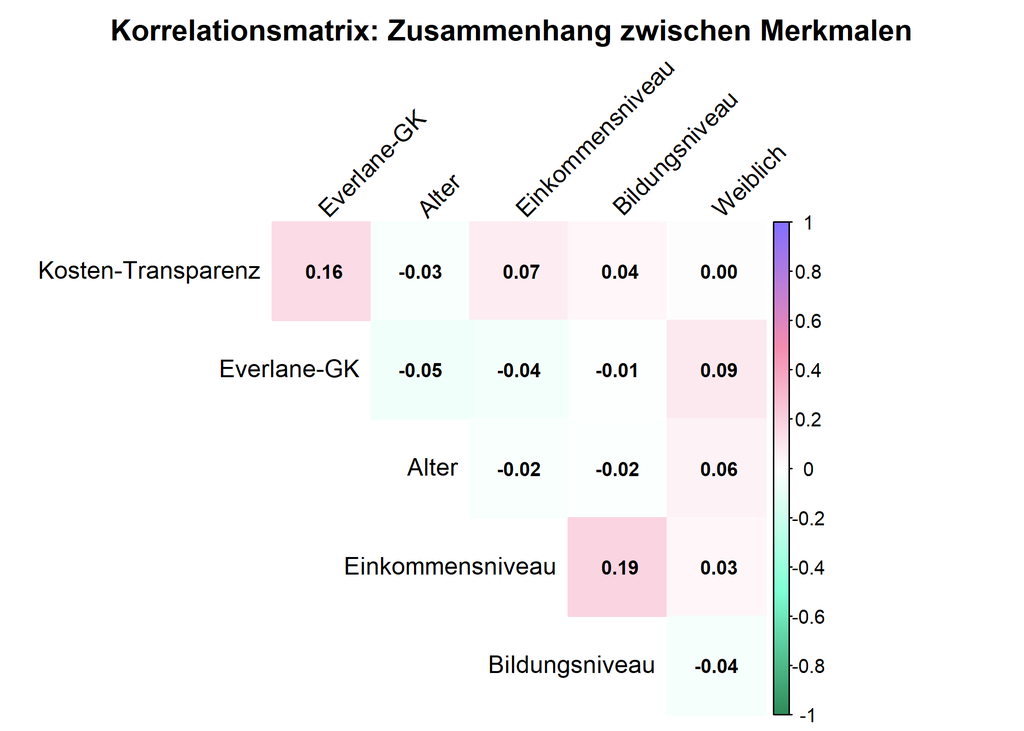

**Beschreibung:**

Die folgende Korrelationsanalyse beruht auf dem Datensatz daten_exp1, der im Rahmen eines experimentellen Designs erhoben wurde. Ziel der Untersuchung ist es herauszufinden, in welchem Ausmaß die Zugehörigkeit zu einer Gruppe mit transparenter Preisgestaltung das Konsumverhalten beeinflusst. Insbesondere geht es um die Entscheidung für eine Gutscheinkarte des Unternehmens Everlane. Zusätzlich wurden demografische Merkmale wie Alter, Einkommen, Bildungsniveau und Geschlecht erhoben.

Die analysierte Korrelationsmatrix zeigt die paarweisen linearen Zusammenhänge zwischen sechs zentralen Merkmalen. Diese Merkmale sind Kosten Transparenz, die Wahl der Everlane Gutscheinkarte, das Alter der Befragten, ihr Einkommensniveau, das Bildungsniveau sowie das Geschlecht, wobei die Variable weiblich binär codiert ist. Aus Gründen der Übersichtlichkeit wird lediglich die obere Hälfte der symmetrischen Matrix dargestellt. Die einzelnen Korrelationskoeffizienten sind sowohl numerisch in den Matrixzellen aufgeführt als auch farblich hervorgehoben. Die Farbskala reicht von minus eins bis plus eins mit Abstufungen von 0.2, wobei der Wert null durch eine weiße Färbung gekennzeichnet ist und somit das Fehlen eines Zusammenhangs signalisiert.

Bezogen auf die Variable Kosten Transparenz zeigt sich ein positiver Zusammenhang mit der Wahl der Everlane Gutscheinkarte. Der Korrelationswert beträgt 0.16. Das Alter weist eine leicht negative Korrelation auf mit einem Wert von minus 0.03. Das Einkommensniveau steht mit 0.07 in einem schwach positiven Zusammenhang zur Treatment-Zugehörigkeit. Das Bildungsniveau zeigt eine Korrelation von 0.04. Für das Geschlecht ergibt sich ein Wert von 0.00, was auf keinen Zusammenhang hinweist.

Die Entscheidung für Everlane ist ebenfalls in einem leicht negativen Verhältnis zu Alter mit einem Wert von minus 0.05, zu Einkommen mit minus 0.04 und zu Bildung mit minus 0.01. Ein leicht positiver Zusammenhang ergibt sich in Bezug auf das Geschlecht mit einem Wert von 0.09. Zwischen den übrigen demografischen Variablen bestehen keine auffälligen Zusammenhänge, mit Ausnahme einer moderaten positiven Beziehung zwischen Einkommen und Bildung mit einem Korrelationswert von 0.19. Dieser Befund entspricht den theoretischen Erwartungen, da ein höheres Bildungsniveau tendenziell mit einem höheren Einkommen einhergeht.

**Interpretation:**

Die positive Korrelation von 0.16 zwischen der Zugehörigkeit zur Gruppe mit transparenter Preisinformation und der Entscheidung für die Everlane Gutscheinkarte deutet auf einen möglichen Zusammenhang hin. Personen, die eine transparente Preisgestaltung vorgelegt bekamen, entschieden sich häufiger für Everlane. Dieser Befund steht im Einklang mit der Annahme, dass Transparenz im Preismodell das Vertrauen der Konsumentinnen und Konsumenten stärkt und dadurch die Wahrscheinlichkeit einer positiven Kaufentscheidung für ein ethisch ausgerichtetes Unternehmen erhöht. Gleichzeitig zeigt der moderate Korrelationswert, dass es neben der Transparenz noch weitere Einflussfaktoren gibt, die das Verhalten der Teilnehmenden beeinflussen.

Es ist jedoch wichtig zu betonen, dass eine Korrelation keine kausalen Rückschlüsse erlaubt. Auch wenn die Zuweisung zum Treatment in diesem Fall zufällig erfolgt ist und somit eine methodisch günstige Ausgangslage für kausale Analysen bietet, bildet die Korrelationsanalyse lediglich das Maß gemeinsamer Variation zweier Variablen ab. Sie sagt nichts über die Richtung oder Ursache des Zusammenhangs aus. Es ist möglich, dass unbeobachtete Drittvariablen sowohl die Treatment-Zugehörigkeit als auch die Entscheidung für Everlane beeinflussen. Daher ist zur Überprüfung eines tatsächlichen kausalen Effekts eine weiterführende Analyse erforderlich, etwa durch multiple Regressionsmodelle, bei denen weitere Einflussgrößen kontrolliert werden.

Im Vergleich zu einem einfachen Mittelwertvergleich zwischen Kontroll- und Treatmentgruppe bietet die Korrelationsmatrix eine umfassendere Einsicht. Sie ermöglicht die gleichzeitige Betrachtung mehrerer Zusammenhänge und hilft dabei, potenzielle Stör- oder Kontrollvariablen zu identifizieren, die in weiteren Analysen berücksichtigt werden sollten. Darüber hinaus erlaubt sie es, auch schwache, aber systematische Beziehungen sichtbar zu machen, die in einem Mittelwertvergleich möglicherweise verborgen geblieben wären. Die Korrelationsmatrix stellt somit ein nützliches Instrument für die explorative Datenanalyse dar und kann eine wichtige Grundlage für Hypothesengenerierung und tiefergehende statistische Verfahren bilden.

7. In Aufgabe 1 und 2 haben Sie gelesen, dass den Teilnehmern ein Angebot gemacht wurde, eine Everlane-Gutscheinkarte anzunehmen. Erzeugen Sie eine geeignete Grafik, die den durchschnittlichen Anteil der angenommenen Angebote (d.h. den Anteil, in dem die Everlane-Karte gewählt wurde) getrennt für die Treatment- und die Kontrollgruppe darstellt. Fügen Sie in der Grafik zusätzlich den Standardfehler der Mittelwerte ein. Führen Sie einen T-Test durch, um zu prüfen, ob der Unterschied im Mittelwert zwischen der Treatment- und Kontrollgruppe statistisch signifikant ist, und geben Sie das Testergebnis (den p-Wert) deutlich sichtbar in der Grafik an. Achten Sie dabei auf eine verständliche Beschriftung Ihrer Grafik sowie auf einen aussagekräftigen Titel.

Beschreiben und interpretieren Sie ihre Grafik. Gehen Sie insbesondere auf folgende Fragen ein:

- Welche Aussage lässt sich auf Basis des durchgeführten T-Tests treffen?
- Welche der in den vorherigen Aufgaben (vgl. Aufgabe 4 und 5) analysierten Faktoren könnten dazu beigetragen haben, dass ein signifikanter Unterschied im Anteil angenommener Everlane-Angebote zwischen Treatment- und Kontrollgruppe beobachtet wird?

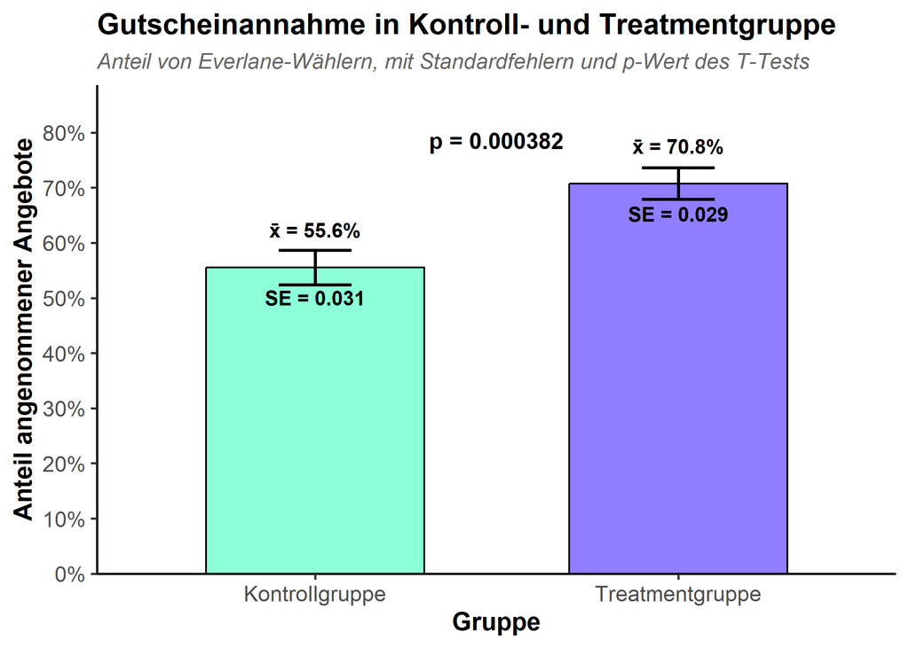

**Interpretation:**

Die dargestellte Grafik zeigt deutlich, dass die Kostentransparenz einen signifikanten Einfluss auf die Wahl der Everlane-Gutscheinkarte hat. Der Unterschied im durchschnittlichen Anteil der angenommenen Angebote in der Treatment-Gruppe (70,8%) im Vergleich zur Kontrollgruppe (55,6%) wird durch den äußerst niedrigen p-Wert von 0.000382 gestützt. Dies deutet darauf hin, dass die Wahrscheinlichkeit, diesen Unterschied zufällig zu beobachten, äußerst gering ist. Die Einführung von Kostentransparenz in der Treatment-Gruppe scheint die Akzeptanz der Everlane-Angebote deutlich zu erhöhen.

Der Standardfehler, der in beiden Gruppen etwa 0.03 beträgt und durch die schwarzen Intervalle dargestellt wird, unterstreicht die Präzision der Schätzung der Mittelwerte. Die relativ kleinen Fehlerbalken im Verhältnis zur Höhe der Balken lassen darauf schließen, dass die Unterschiede zwischen den Gruppen nicht durch hohe Streuung innerhalb der Gruppen erklärt werden können.

Zusätzlich zu den beobachteten Effekten der Kostentransparenz ist es wichtig, die potenzielle Rolle von weiteren Einflussfaktoren zu berücksichtigen. In den vorhergehenden Aufgaben wurden mögliche systematische Unterschiede zwischen den Gruppen in Bezug auf Alter, Geschlecht, Einkommen und Bildung untersucht. Diese demografischen und sozioökonomischen Variablen könnten theoretisch zu unterschiedlichen Präferenzen und Entscheidungen geführt haben. Zum Beispiel könnten ältere Teilnehmer oder Teilnehmer mit höherem Einkommen unterschiedlich auf Angebote reagieren, auch wenn die Zuordnung zu den Gruppen zufällig war. Daher ist es wichtig, solche Faktoren in zukünftigen Analysen zu berücksichtigen, um sicherzustellen, dass die Ergebnisse der Behandlung (Kostentransparenz) nicht durch unbeabsichtigte Gruppenunterschiede verzerrt werden.

Insgesamt bestätigt die Analyse, dass Kostentransparenz effektiv das Konsumentenverhalten beeinflusst. Die Farbwahl “Lila” für die Treatment-Gruppe und Türkis” für die Kontrollgruppe unterstützt den visuellen Vergleich und macht es den Betrachtern leicht, den Effekt der Treatment-Bedingung zu erkennen. Diese Erkenntnisse sind für Unternehmen, die ihre Marketing- und Verkaufsstrategien überdenken, von hoher Bedeutung.

In den vorherigen Aufgaben des Projekts haben Sie sich bereits intensiv mit dem Experiment 1 auseinandergesetzt, in dem untersucht wurde, ob und wie die Offenlegung von Produktionskosten - also Kostentransparenz - das Konsumverhalten beeinflusst. Es wurde gezeigt: Wenn Konsument:innen transparent mitgeteilt wird, wie sich die Kosten eines Produkts zusammensetzen, steigt ihre Bereitschaft, bei dem entsprechend transparenten Unternehmen einzukaufen.

Diese Ergebnisse legen nahe, dass die Offenlegung sensibler Unternehmensinformationen (wie Produktionskosten) das Vertrauen der Konsument:innen in das Unternehmen stärkt und sie somit eher zu einem Kauf motiviert.

Doch was genau ist der psychologische Mechanismus hinter dieser Wirkung? Ist es tatsächlich das Vertrauen in das Unternehmen, das durch die Offenlegung sensibler Informationen gestärkt wird - und in der Folge die Kaufbereitschaft erhöht?

Um genau diese Frage zu beantworten, führen die Autoren ein weiteres Experiment durch, das den vermuteten psychologischen Vermittlungsmechanismus des Vertrauens genauer untersucht. Dabei wurde geprüft, ob Vertrauen tatsächlich als Mediator zwischen Kostentransparenz und Kaufinteresse wirkt. Hierzu wurde ein kontrolliertes Online-Experiment mit über 600 Teilnehmer:innen durchgeführt. Die Teilnehmenden wurden zufällig einer von zwei Bedingungen zugewiesen:

- In der **Kostentransparenz-Gruppe** (Treatment) wurde zusätzlich eine detaillierte Aufschlüsselung der Produktionskosten angegeben. Diese beinhaltete die einzelnen Kostenkomponenten (z.B. Kakaobutter, Verpackung, Arbeitskosten) sowie die Gesamtkosten der Schokoladentafel (vgl. Abbildung 2 im Anhang).
- In der **Kontrollgruppe** sahen die Teilnehmer die Verpackung einer fiktiven Schokoladenmarke namens „Cocoa Passion“. Diese enthielt nur die üblichen Informationen wie Zutaten, Nährwerte und eine Produktbeschreibung.

Ziel war es, zu untersuchen, ob die Offenlegung dieser sensiblen Informationen das Vertrauen der Konsument:innen in die Marke stärkt - und ob dieses Vertrauen wiederum die Kaufbereitschaft beeinflusst. In den nächsten Aufgaben werden Sie diese Studie genauer beleuchten, analysieren und evaluieren, ob sich die Hypothese empirisch bestätigen lässt.

8. Lesen Sie die Daten des zweiten Experiments (`Experiment2.csv`) in R ein. Nennen Sie den Datensatz `daten_exp2`. Benennen Sie die Variable `cost` in `treatment` um.

Untersuchen Sie, ob sich die Teilnehmer, die die Verpackung mit transparenter Kosteninformation gesehen haben, systematisch von jenen unterscheiden, die nur die Kontrollversion gesehen haben.

Erstellen Sie hierfür eine Balancing-Tabelle, in der Sie die Mittelwerte von Alter (age), Geschlecht (female), Einkommensstufe (income), Bildungsniveau (educ), Vertrauen (trust) und Kaufbereitschaft (wtb) zwischen den beiden Gruppen vergleichen, die Differenzen berechnen und mithilfe von T-Tests prüfen, ob diese Unterschiede statistisch signifikant sind. Nehmen Sie weiterhin die Anzahl an Beobachtungen in der Treatment- und in der Kontrollgruppe in ihre Tabelle mit auf.

Beschreiben und interpretieren Sie ihre Tabelle. Gehen Sie dabei insbesondere auf folgende Fragen ein:

- Was versteht man unter der Variable `wtb`?
- Was lässt sich aus der Größen der Stichprobe ableiten?
- Wo könnte es bei einer Regression (oder einem sonstigen Vergleich der Gruppen) zu Problemen kommen und was wären mögliche Auswirkungen?

*Hinweis:* Für die Beschreibung der `wtb` können Sie das bereitgestellte Readme nutzen.

Balancing-Tabelle: Vergleich Treatment. vs. Kontrollgruppe im Experiment 2

[output not shown]

Note:  
Hinweis: Vergleich von 601 vollständigen Beobachtungen davon 301 Kontrollgruppe und 300 Treatmentgruppe

**Beobachtung**

Die folgende Balancing-Tabelle vergleicht zentrale demografische und verhaltensbezogene Merkmale der Teilnehmer des zweiten Experiments zwischen der Kontroll- und der Treatmentgruppe. Die Tabelle basiert auf 601 vollständigen Beobachtungen: 301 in der Kontrollgruppe und 300 in der Treatmentgruppe. Die in der Tabelle dargestellten Variablen umfassen Alter (age), Geschlecht (female), Einkommensniveau (income), Bildungsniveau (educ), Vertrauen (trust) und Kaufbereitschaft (wtb). Für jede Variable werden die Mittelwerte beider Gruppen, die Differenz dieser Mittelwerte sowie die p-Werte eines T-Tests auf Gleichheit der Mittelwerte berichtet.

Die Variable wtb (willingness to buy) misst die Kaufbereitschaft der Teilnehmer auf einer siebenstufigen Skala, wobei 1 „Überhaupt nicht wahrscheinlich“ und 7 „Sehr wahrscheinlich“ bedeutet. Sie gibt an, wie wahrscheinlich es ist, dass ein Teilnehmer das Produkt (in diesem Fall mit oder ohne transparente Kosteninformation) kaufen würde.

**Interpretation**

Der signifikant höhere trust-Wert in der Treatmentgruppe könnte insbesondere problematisch sein, da Vertrauen mit höherer Kaufbereitschaft korrelieren kann. Wenn also die Treatmentgruppe tendenziell vertrauensvoller ist, könnte ein Teil des Unterschieds in der Kaufbereitschaft auf diesen Unterschied zurückzuführen sein – nicht allein auf die transparente Kosteninformation. Auch das niedrigere Alter in der Treatmentgruppe könnte relevant sein, falls jüngere Teilnehmer systematisch anders auf das Treatment reagieren.

Diese Unterschiede sollten in einer weiterführenden Regressionsanalyse kontrolliert werden. Variablen wie Alter und Vertrauen sollten als Kovariaten aufgenommen werden, um sicherzustellen, dass der geschätzte Effekt der transparenten Kosteninformation auf die Kaufbereitschaft nicht verzerrt wird. Werden solche Störvariablen ignoriert, besteht die Gefahr einer Fehlschätzung des kausalen Effekts – entweder durch Überschätzung (positive Verzerrung) oder Unterschätzung (negative Verzerrung) der tatsächlichen Wirkung.

Die nahezu gleich große Stichprobe in beiden Gruppen (301 vs. 300) ist positiv zu bewerten, da sie eine solide Grundlage für Gruppenvergleiche bildet und die Power statistischer Tests erhöht. Eine ungleiche Gruppengröße hätte potenziell die Teststärke reduziert oder die Varianz der Schätzungen erhöht.

9. In ihrem Datensatz gibt es einige Beobachtungen ohne vorhandene Werte. Behalten Sie nur die Beobachtungen bei denen vollständige Werte vorliegen. Erzeugen Sie eine geeignete Grafik, welche den durchschnittlichen Anteil der ‘Kaufbereitschaft’ im zweiten Experiment für die Treatment- und Kontrollgruppe darstellt.

Die Grafik soll:

- die Mittelwerte der Kaufbereitschaft für beide Gruppen zeigen,
- die zugehörigen Standardfehler als Fehlerbalken visualisieren und
- das Ergebnis des T-Tests, der die Mittelwertdifferenz prüft, direkt in die Grafik integrieren.

Beschreiben und interpretieren Sie ihre Grafik.

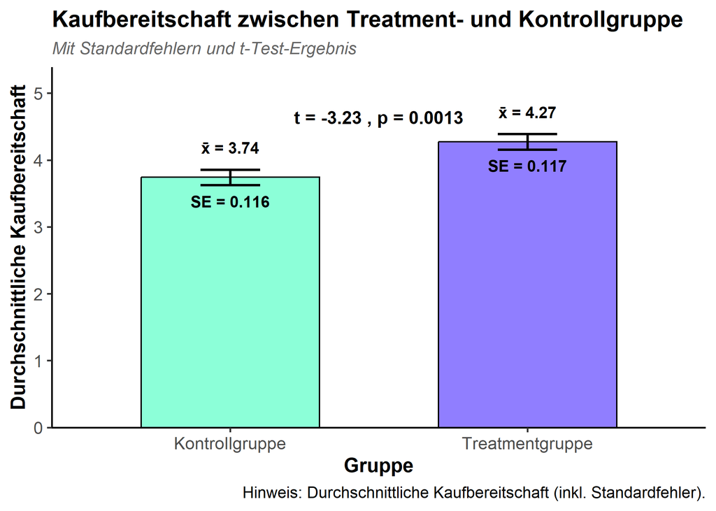

**Beschreibung:**

Die Grafik stellt die durchschnittliche Kaufbereitschaft im zweiten Experiment für zwei Gruppen dar: die Kontrollgruppe und die Treatmentgruppe. Auf der y-Achse ist die durchschnittliche Kaufbereitschaft im Mittelwert angegeben, auf der x-Achse die beiden Gruppen. Jeder Balken zeigt den Gruppenmittelwert (Kontrollgruppe = 3,74; Treatmentgruppe = 4,27), welche oben durch eine Fehlerbalkenlinie ergänzt sind, die den Standardfehler (SE = 0,116 bzw. SE = 0.117) darstellen. Über den Balken sind die exakten Werte “x̄ = …” und “SE = …” als Beschriftung angebracht. In der Bildmitte oberhalb der Balken ist zusätzlich das Ergebnis des t-Tests (t = -3,23, p = 0,0013) zur Überprüfung der Mittelwertdifferenz dargestellt. Die Balken sind in unterschiedlichen Farben visualisiert, wobei die Kontrollgruppe in aquamarin und die Treatmentgruppe in violett gefärbt sind.

**Interpretation:**

Die Treatmentgruppe weist einen klar höheren Mittelwert der Kaufbereitschaft (4,27) als die Kontrollgruppe (3,74), während die Standardfehler beider Gruppen relativ gering und nahezu identisch sind. Dies weist auf eine stabile Messung hin. Das signifikante t-Testergebnis (p = 0,0013 < 0,05) bestätigt, dass dieser Unterschied nicht auf Zufall basiert, sondern statistisch belastbar ist. Daher könnte sich erschließen lassen, dass die Kostentransparenz einen positiven Effekt auf die Kaufbereitschaft hatte und die Probanden der Treatmentgruppe im Durchschnitt deutlich kaufbereiter waren als diejenigen in der Kontrollgruppe. Es lässt sich ein direkter Effekt der Kostentransparenz auf die Kaufbereitschaft erkennen, jedoch lässt sich noch nicht sagen, wie signifikant dieser ist. So könnte sich die Transparenz auch nur auf eine andere Variable auswirken, welche wiederum die Kaufbereitschaft beeinflusst. Anhand dieser Grafik lässt sich nur sagen, dass Menschen mit Einsicht auf die Kostenaufschlüsselung dazu neigen, eher zu kaufen.

Nachdem Sie nun die Differenzen in der Kaufabsicht zwischen der Treatment- und der Kontrollgruppe im zweiten Experiment überprüft und getestet haben, geht es im nächsten Schritt darum, den möglichen Mediator Vertrauen genauer zu untersuchen. Hierfür sollen Sie sich in einem ersten Schritt das Vertrauen der Personen allgemein anschauen, um einen Eindruck zu dieser wichtigen Variable zu bekommen. Dafür werden Personen anhand **hohem und niedrigem** Vertrauen und deren Kaufbereitschaft für das Produkt unterteilt.

10. Erstellen Sie eine oder mehrere geeignete Grafik(en), die den Zusammenhang zwischen Vertrauen (Trust) und der Kaufabsicht (WTB) **unabhängig** der beiden Treatment- und Kontrollgruppen darstellen. Achten Sie auf eine passende Darstellung der Informationen.

Die Grafik(en) sollen folgende Informationen enthalten:

- Unterteilen Sie ihre Daten in Personen mit `hohem` und `niedrigem` Vertrauen. Nutzen Sie für die Unterteilung den Median des Vertrauens in ihren Daten als Schwellenwert.
- Abhängig der Einstufungen in `hohes` und `niedriges` Vertrauen soll nun die durchschnittliche Kaufbereitschaft dargestellt werden. Hier soll die Grafik so dargestellt werden, dass auf der x-Achse das Vertrauensniveau (“hoch” und “niedrig”) und auf der y-Achse die entsprechende Kaufbereitschaft abgebildet wird.
- Berechnen Sie weiterhin die Mittelwerte der beiden Vertrauensgruppen und visualisieren diese in geeigneter Art und Weise in ihren Grafik(en).
- Führen Sie einen t-Test durch, um zu prüfen, ob die Mittelwertsunterschiede zwischen den beiden Vertrauensgruppen statistisch signifikant sind. Geben Sie den p-Wert in der Grafik an.

Beschreiben und interpretieren Sie ihre Grafik(en). Beantworten Sie insbesondere folgende Fragen:

- Welche Implikationen hat ein signifikanter Unterschied für die Rolle von Vertrauen auf Kaufentscheidungen?
- Wie stark unterscheidet sich die Kaufbereitschaft zwischen Personen mit hohem und niedrigem Vertrauen?
- Könnte auf Basis ihrer Darstellung Vertrauen als Mediator zwischen dem Treatment und der Kaufbereitschaft fungieren?

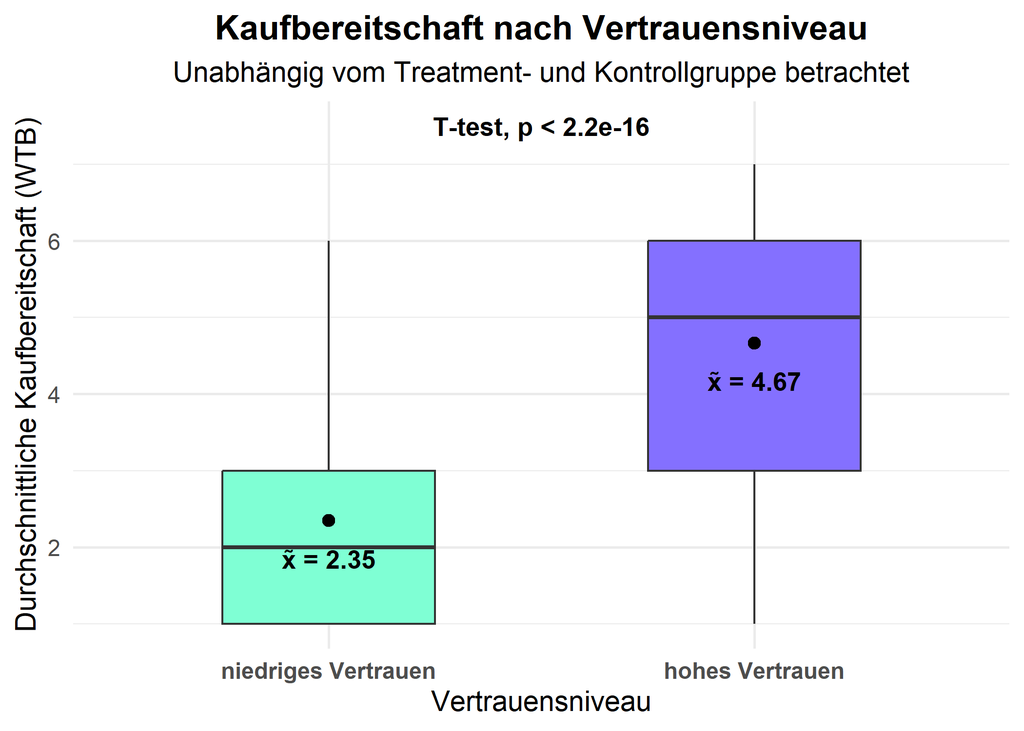

**Interpretation:**

Daraus lässt sich ableiten, dass Personen mit höherem Vertrauen eher bereit sind, ein wahrgenommenes Risiko – sei es finanziell oder qualitativ – einzugehen. Für die Praxis bedeutet das: Maßnahmen, die Vertrauen stärken, wie transparente Preisgestaltung, Gütesiegel oder glaubwürdige Erfahrungsberichte, können die Kaufbereitschaft erheblich erhöhen.

Ob Vertrauen jedoch als vermittelnde Variable zwischen dem Treatment und der Kaufbereitschaft fungiert, lässt sich aus dieser Analyse allein noch nicht abschließend beurteilen. Zwar zeigen die bisherigen Ergebnisse, dass sowohl das Treatment Vertrauen beeinflusst als auch Vertrauen mit höherer Kaufbereitschaft einhergeht. Doch eine formale Mediation erfordert, dass auch der direkte Effekt des Treatments auf die Kaufbereitschaft nach Kontrolle für Vertrauen signifikant sinkt. Erst eine entsprechende Mediationsanalyse – etwa durch ein Pfadmodell oder mehrstufige Regressionsansätze – könnte dies überprüfen. Bis dahin bleibt die Rolle von Vertrauen als kausaler Mediator theoretisch plausibel, aber empirisch noch offen.

# Regressionsanalyse

Sie haben nun ihren Datensatz kennengelernt und es scheint so, als ob insbesondere Personen, welche transparente Kosten sehen, dazu neigen, das Produkt zu kaufen. Doch um ihre deskriptiven Analysen zu erhärten, wollen Sie im folgenden eine Analyse mittels Regressionen durchführen.

11. Betrachten Sie hier noch einmal das erste Experiment (`daten_exp1`). Führen Sie eine Regression durch, bei der Ihnen `everlane` als abhängige Variable dient. Als erklärende Variable nutzen Sie das `treatment`. Erstellen sie eine weitere Regression, die zusätzlich noch für die folgenden Variablen kontrolliert:
- Alter
- Bildungsstufe
- Einkommen
- Geschlecht

Stellen Sie die Regressionsergebnisse in einer Tabelle mit stargazer oder modelsummary dar!

Beschreiben und interpretieren Sie ihre Ergebnisse. Gehen Sie insbesondere auf folgende Fragen ein:

- Lässt sich der Effekt des Treatments auf die Entscheidung der Kunden kausal interpretieren?
- Ist es wichtig auf weitere Faktoren zu kontrollieren?
- Beziehen Sie sich hier auch auf die Ergebnisse aus Aufgabe 5.

**Lineare Regressionsergebnisse für die Everlane-Wahl**

**Abhängige Variable: Everlane-Wahl**

|  | Erste Entscheidung | Zweite Entscheidung |
| --- | --- | --- |
| (Konstante) | 0.556*** | 0.686*** |
|  | (0.030) | (0.132) |
| Kostentransparenz (Treatment) | 0.152*** | 0.155*** |
|  | (0.042) | (0.042) |
| Alter |  | -0.002 |
|  |  | (0.002) |
| Bildungsniveau |  | -0.001 |
|  |  | (0.026) |
| Einkommen |  | -0.012 |
|  |  | (0.009) |
| Weiblich |  | 0.091* |
|  |  | (0.042) |
| R² | 0.025 | 0.039 |
| Adj. R² | 0.023 | 0.030 |
| F-Statistik | 12.80 (df = 1, 503) | 4.07 (df = 5, 499) |
| AIC | 690.06 | 690.55 |
| BIC | 702.73 | 720.12 |
| Beobachtungen | 505 | 505 |

* p < 0.05, ** p < 0.01, *** p < 0.001

**Beschreibung:**

In der Regressionsanalyse wurden zwei Modelle geschätzt, in denen untersucht wird, ob die Anzeige transparenter Kosten einen Einfluss auf die Entscheidung hat, Everlane zu wählen. In beiden Modellen ist die abhängige Variable die Wahl von Everlane (Ja = 1, Nein = 0). Das erste Modell enthält nur eine erklärende Variable, nämlich das Treatment, das angibt, ob eine Person transparente Kosten gesehen hat oder nicht. Der dazugehörige Regressionskoeffizient zeigt, wie stark sich die Wahrscheinlichkeit, Everlane zu wählen, zwischen Personen mit und ohne Treatment unterscheidet. Im zweiten Modell werden zusätzlich vier Kontrollvariablen einbezogen: Alter, Bildungsniveau, Einkommen und Geschlecht. Dadurch kann geprüft werden, ob der Zusammenhang zwischen Treatment und Everlane-Wahl bestehen bleibt, wenn diese demografischen Merkmale berücksichtigt werden.Für jede Variable wird ein geschätzter Regressionskoeffizient angegeben, der zeigt, wie stark sich die abhängige Variable verändert, wenn sich die jeweilige unabhängige Variable um eine Einheit verändert, wobei alle anderen Variablen konstant gehalten werden. In Klammern hinter den Koeffizienten stehen die Standardfehler, die Auskunft über die statistische Unsicherheit der Schätzungen geben. Zusätzlich sind Sternchen angegeben, die das Signifikanzniveau anzeigen: Ein, zwei oder drei Sterne bedeuten, dass der geschätzte Effekt mit einer hohen Wahrscheinlichkeit nicht zufällig ist. Am unteren Rand der Tabelle finden sich Informationen zur Anzahl der Beobachtungen im Modell sowie zum Bestimmtheitsmaß R² und dem adjustierten R². Diese Werte zeigen, wie viel der Gesamtvarianz in der abhängigen Variable durch die erklärenden Variablen im Modell aufgeklärt wird.

**Interpretation:**

Da die Zuteilung zu Kontroll- und Treatmentgruppe im Rahmen des Experiments randomisiert erfolgte und die Balancing-Tabelle aus Aufgabe 5 bestätigt hat, dass zwischen den beiden Gruppen keine systematischen Unterschiede in Bezug auf Alter, Geschlecht, Einkommen und Bildungsniveau bestehen, kann der geschätzte Effekt des Treatments als kausal interpretiert werden. Der geschätzte Koeffizient von etwa 0,15 bedeutet konkret, dass die Anzeige transparenter Kosten die Wahrscheinlichkeit, dass sich Teilnehmende für Everlane entscheiden, um 15 Prozentpunkte erhöht. Dieser Effekt bleibt auch dann stabil und hochsignifikant, wenn zusätzlich für die genannten demografischen Merkmale kontrolliert wird. Der Vergleich der beiden Regressionsmodelle zeigt, dass der Treatment-Effekt mit und ohne Kontrolle nahezu identisch bleibt (0,152 vs. 0,155), was für die Robustheit der Schätzung spricht. Die Hinzunahme der Kontrollvariablen steigert das erklärte Varianzmaß (R²) von 2,5 % auf 3,9 %, was auf eine geringfügige Verbesserung der Modellgüte hinweist. Von den berücksichtigten Kovariaten zeigt einzig das Geschlecht einen signifikanten Einfluss: Weibliche Teilnehmende wählen Everlane im Durchschnitt mit einer um etwa neun Prozentpunkte höheren Wahrscheinlichkeit als männliche Teilnehmende. Alter, Bildungsniveau und Einkommen haben hingegen keinen signifikanten Einfluss auf die Entscheidung. In Bezug auf die Ergebnisse aus Aufgabe 5 ist hervorzuheben, dass vor Durchführung der Regression keine signifikanten Unterschiede zwischen Treatment- und Kontrollgruppe festgestellt wurden. Lediglich das Einkommen wies eine marginale Abweichung mit einem p-Wert von 0,098 auf. Durch die Aufnahme aller relevanten demografischen Variablen in die Regressionsanalyse werden selbst solche kleineren Ungleichgewichte statistisch ausgeglichen. Dadurch kann mit hoher Sicherheit ausgeschlossen werden, dass der beobachtete Effekt des Treatments durch verbliebene Störfaktoren beeinflusst wurde, und der Effekt lässt sich entsprechend als kausal interpretieren.

Während die bisherigen Analysen zeigen, dass das Treatment einen Effekt hat, stellt sich nun die Frage, warum das so ist. Nun sollten Sie im weiteren Verlauf durch vertiefende Regressionsanalysen prüfen, ob dies auf das Vertrauen der Kunden zurückzuführen ist. Dazu betrachten Sie noch einmal den Datensatz zu Experiment 2 (`daten_exp2`) und untersuchen, ob das Treatment (Kunden sehen transparente Kostenstruktur) zu einer höheren Kaufabsicht führt, weil sie das Vertrauen der Konsumenten in das Unternehmen stärkt.

12. Schauen Sie sich den Einfluss der Kostentransparenz auf die Kaufabsicht in den folgenden zwei Regressionen genauer an und zeigen Sie ihre Ergebnisse nebeneinander:

**1. Regression:** Abhängige Variable ist die Kaufabsicht; die erklärende Variable ist das Treatment.

**2. Regression:** Wie in der 1. Regression, doch kontrollieren Sie hier zusätzlich auf die Variablen Alter, Einkommensniveau, Bildungsstufe und Geschlecht.

Stellen Sie die Regressionsergebnisse in einer Tabelle mit stargazer oder modelsummary dar!

Beschreiben und interpretieren Sie ihre Ergebnisse allgemein. Gehen Sie weiterhin auch speziell auf folgende Fragen ein:

- Sollten die Kontrollvariablen in ihrer zweiten Regression den Koeffizienten des Treatments ändern? Was würden Sie erwarten und warum? Nutzen Sie hierzu die Ergebnisse aus Aufgabe 8.
  - Vergleichen Sie die Regressionskoeffizienten der Treatment-Variable in der ersten und zweiten Regression. Gibt es hier einen signifikanten Unterschied in der Größe des Effekts?
- Bringt ihnen die Regression Vorteile gegenüber einer reinen Darstellung der Mittelwerte wie in Aufgabe 9?
- Ist der Effekt des Treatments auf die Kaufabsicht ihrer Ansicht nach kausal interpretierbar?
  - Welche Voraussetzungen müssen erfüllt sein, damit man diesen Regressionskoeffizienten als kausalen Effekt interpretieren kann?
  - Überlegen Sie sich, wie sich das Ergebnis verändern würde, wenn zusätzlich Vertrauen (trust) in das Modell aufgenommen wird. Würde sich der Effekt von `treatment` verändern? Warum oder warum nicht?

**Einfluss von Kostentransparenz auf Kaufabsichten**

**Abhängige Variable: Kaufabsicht**

|  | Erste Entscheidung | Zweite Entscheidung |
| --- | --- | --- |
| (Konstante) | 3.741*** | 3.702*** |
|  | (0.116) | (0.470) |
| Kostentransparenz (Treatment) | 0.532** | 0.501** |
|  | (0.165) | (0.166) |
| Alter |  | -0.013 |
|  |  | (0.007) |
| Einkommen |  | 0.023 |
|  |  | (0.036) |
| Bildungsniveau |  | 0.102 |
|  |  | (0.099) |
| Weiblich |  | -0.001 |
|  |  | (0.168) |
| R² | 0.017 | 0.025 |
| Adj. R² | 0.015 | 0.016 |
| F-Statistik | 10.43 (df = 1, 599) | 3.01 (df = 5, 595) |
| AIC | 2554.98 | 2558.35 |
| BIC | 2568.18 | 2589.14 |
| Beobachtungen | 601 | 601 |

* p < 0.05, ** p < 0.01, *** p < 0.001

**Beschreibung:**

Im Rahmen der Analyse wurden zwei lineare Regressionsmodelle geschätzt, um den Einfluss der Kostentransparenz auf die Kaufabsicht der Teilnehmenden zu untersuchen. In beiden Modellen ist die abhängige Variable die auf einer Skala von 1 bis 7 gemessene Kaufbereitschaft (WTB). Im ersten Modell wurde ausschließlich das Treatment – also die Anzeige einer transparenten Kostenstruktur – als erklärende Variable aufgenommen. Das zweite Modell erweitert die Analyse um vier soziodemografische Kontrollvariablen: Alter, Einkommensniveau, Bildungsniveau und Geschlecht. Für alle Variablen wurden Regressionskoeffizienten sowie die zugehörigen Standardfehler geschätzt. Darüber hinaus werden Kennzahlen wie R², der AIC- und BIC-Wert sowie die Anzahl der Beobachtungen angegeben, um die Modellgüte und Vergleichbarkeit zu bewerten. Beide Modelle basieren auf insgesamt 601 vollständigen Beobachtungen. Das Ziel dieser Analyse besteht darin, den Einfluss des Treatments sowohl isoliert als auch unter Berücksichtigung potenzieller Störfaktoren zu quantifizieren und zu überprüfen, ob der Effekt robust gegenüber zusätzlichen Einflussgrößen ist.

**Interpretation:**

Die Regressionsanalyse zeigt, dass die Anzeige transparenter Kosten einen signifikanten und positiven Einfluss auf die Kaufabsicht der Teilnehmenden hat. In beiden Modellen ist der Effekt stabil und liegt zwischen 0,532 im ersten Modell und 0,501 im zweiten Modell – ein Unterschied, der sowohl statistisch als auch inhaltlich vernachlässigbar ist. Dies spricht dafür, dass der Effekt robust ist und nicht durch demografische Merkmale wie Alter, Einkommen, Bildungsniveau oder Geschlecht verzerrt wird. Diese Einschätzung deckt sich mit den Ergebnissen aus Aufgabe 8, in der die Balancing-Tabelle zeigte, dass bis auf das Alter keine signifikanten Unterschiede zwischen Treatment- und Kontrollgruppe vorlagen. Entsprechend war nicht zu erwarten, dass sich der Effekt nach Kontrolle dieser Variablen stark verändert. Im Vergleich zur Mittelwertanalyse aus Aufgabe 9 bietet die Regressionsanalyse mehrere Vorteile. Sie ermöglicht es, die Wirkung des Treatments unter Kontrolle weiterer Einflussfaktoren zu untersuchen und statistisch zu isolieren. Dadurch lassen sich nicht nur potenzielle Verzerrungen vermeiden, sondern auch die Signifikanz der Effekte direkt bestimmen. Zusätzlich liefert das Regressionsmodell Informationen zur Modellgüte und erlaubt die gleichzeitige Berücksichtigung mehrerer erklärender Variablen, was die Aussagekraft der Analyse deutlich erhöht. Da es sich um ein experimentelles Design mit randomisierter Zuteilung handelt, kann der geschätzte Treatment-Effekt grundsätzlich kausal interpretiert werden. Die Voraussetzung hierfür ist, dass es keine systematischen Unterschiede zwischen den Gruppen gibt und dass keine Selektionsmechanismen oder Verzerrungen durch unbeobachtete Drittvariablen vorliegen – beides wurde durch die Randomisierung und die Balancing-Ergebnisse weitgehend erfüllt. Wenn zusätzlich die Variable Vertrauen (trust) in das Modell aufgenommen würde, wäre zu erwarten, dass sich der Effekt des Treatments verringert. Denn Vertrauen wird durch das Treatment beeinflusst und steht gleichzeitig in engem Zusammenhang mit der Kaufabsicht. Vertrauen fungiert daher vermutlich als vermittelnde Variable (Mediator). Wird es in die Regression aufgenommen, erklärt es einen Teil des Zusammenhangs zwischen Kostentransparenz und Kaufabsicht, sodass der direkte Effekt des Treatments kleiner ausfällt. Dies wäre ein erster Hinweis auf einen indirekten Wirkmechanismus über Vertrauen.

Sie haben nun gesehen, dass es auch hier einen direkten Effekt des Treatments (transparente Kostenstrukur) auf die Kaufabsicht gibt. Doch um die dahinter liegenden Mechanismen zu verstehen, müssen Sie tiefer in psychologische Prozesse eintauchen. Experiment 2 zeigt dafür ein entsprechendes Design, um zu testen, ob Vertrauen als vermittelnder Mechanismus eine Rolle spielt. Im nächsten Schritt analysieren Sie nun selbst diese Beziehung mit theoretischen Modellen und Regressionsmethoden, um ein Gefühl dafür zu bekommen, wie sich direkte und indirekte Effekte voneinander unterscheiden.

13. Bevor Sie im nächsten Schritt ein konkretes DAG zu einem psychologischen Mediationsmechanismus erstellen, machen Sie sich zunächst mit den theoretischen Grundlagen von Directed Acyclic Graphs (DAGs) vertraut. DAGs (gerichtete azyklische Graphen) sind ein nützliches Werkzeug in der Kausalanalyse.

Beantworten Sie folgende theoretische Fragen zu DAGs:

- Wofür werden DAGs in der empirischen Forschung verwendet?
- Nennen und beschreiben Sie zwei zentrale Knotentypen in einem DAG: Confounder und Mediator.
- Worin besteht der zentrale Unterschied, ob Vertrauen als Kontrollvariable (Confounder) oder als Mediator behandelt wird - und warum ist Letzteres entscheidend für das Verständnis psychologischer Prozesse im vorliegenden Experiment?

**Wofür werden DAGs in der empirischen Forschung verwendet?**

DAGs dienen in der empirischen Forschung als visuelles Werkzeug zur Darstellung kausaler Beziehungen zwischen Variablen. Dabei können Hypothesen über Ursache-Wirkungs-Zusammenhänge klar dargestellt werden. Der “Directed”-Part zeigt dabei die Richtung des Einflusses an. Dabei ist es wichtig, dass diese nur azyklisch (daher “Acyclic”), also ohne Rückschleifen auftreten dürfen. D.h. eine Variable kann nicht indirekt wieder auf sich selbst zurückwirken. In der empirischen Forschung ist dies wichtig um kausale Annahmen explizit zu machen oder zu erkennen, welche Variablen man kontrollieren sollte.

**Nennen und beschreiben Sie zwei zentrale Knotentypen in einem DAG: Confounder und Mediator.**

Confounder: Ein Confounder ist eine Variable, die sowohl die unabhängige Variable als auch die abhängige Variable kausal beeinflusst. Confounder erzeugen sogenannte Scheinkorrelationen und können die Schätzung eines kausalen Effekts verzerren, wenn sie nicht kontrolliert werden. Im DAG zeigen die Pfeile des Confounders also auf beide Variablen. Ein Beispiel für einen Confounder könnte “allgemeines Markenvertrauen” sein. Dabei könnte dies beeinflussen wie arg jemand die Kostentransparenz beachtet (Treament), als auch die Bereitschaft am Ende das Produkt zu kaufen (Outcome). Berücksichtigt (bzw. kontrolliert) man dies nicht, könnte der Effekt der Kostentransparenz überschätzt werden.

Mediator: Ein Mediator ist eine Variable, die den kausalen Effekt der unabhängigen Variable auf die abhängige Variable vermittelt. Das bedeutet: Die unabhängige Variable beeinflusst den Mediator und dieser wirkt wiederum auf die abhängige Variable. Mediatoren erklären also den psychologischen Wirkmechanismus, der hinter einem beobachteten Effekt steckt. Im Beispiel könnte Vertrauen ein solcher Mediator sein. Vertrauen wäre ein Mediator, wenn es durch die Kostentransparenz gestärkt wird und sich durch gesteigertes Vertrauen wiederum die Kaufabsicht erhöht. Ein Mediator erlaubt es also, zwischen dem direkten Effekt (Kostentransparenz -> Kaufabsicht) und dem indirekten Effekt (Kostentransparenz -> Vertrauen -> Kaufabsicht) zu unterscheiden.

Es ist zu sehen, dass Vertrauen sowohl Confounder, als auch Mediator sein könnte.

**Worin besteht der zentrale Unterschied, ob Vertrauen als Kontrollvariable (Confounder) oder als Mediator behandelt wird – und warum ist Letzteres entscheidend für das Verständnis psychologischer Prozesse im vorliegenden Experiment?**

Der zentrale Unterschied zwischen einem Confounder und einem Mediator liegt in ihrer kausalen Rolle innerhalb eines Wirkzusammenhangs: Wird Vertrauen als Confounder behandelt, bedeutet das, dass es bereits vor der Manipulation (Kostentransparenz) vorhanden ist und sowohl das Treatment (z.B. wie stark jemand auf transparente Informationen achtet) als auch das Outcome (Kaufabsicht) beeinflusst. In diesem Fall müsste Vertrauen kontrolliert werden, um eine Verzerrung des Effekts der Kostentransparenz auf die Kaufabsicht zu vermeiden.Wird Vertrauen hingegen als Mediator behandelt, dann ist es eine Variable, die vom Treatment beeinflusst wird und selbst den Outcome beeinflusst. Vertrauen erklärt also den psychologischen Wirkmechanismus, durch den Kostentransparenz die Kaufabsicht erhöht. In diesem Fall darf Vertrauen nicht einfach als Kontrollvariable behandelt werden, sondern muss gezielt modelliert werden, um den indirekten Effekt zu messen. Im vorliegenden Experiment ist Letzteres entscheidend, da es explizit darum geht, die psychologischen Prozesse zu verstehen, die hinter dem beobachteten Verhalten stehen. Die Forscher vermuten, dass Kostentransparenz das Vertrauen der Konsumenten stärkt und dass dieses gesteigerte Vertrauen wiederum zu einer höheren Kaufabsicht führt.

14. Nutzen Sie nun das Directed Acyclic Graph (DAG), um die Beziehungen zwischen den Variablen Treatment (T), Vertrauen (V) und Kaufbereitschaft (K) zu analysieren und den vermuteten Mediationsmechanismus zu untersuchen.

Beschreiben und interpretieren Sie ihr DAG und die Beziehungen zwischen den Variablen. Gehen Sie insbesondere auf folgende Fragen und Aspekte ein:

- Begründen und erklären Sie die Struktur und den Aufbau ihres DAGs.
- Welche Annahmen müssen getroffen werden, damit Vertrauen tatsächlich als Mediator interpretiert werden kann?
- Welche Verzerrungen oder Störfaktoren könnten den Mediator-Effekt von Vertrauen beeinflussen? Wie könnte dies die Ergebnisse verzerren?

*Hinweis 1:* Für die Erstellung des DAGs können Sie das Paket `dagify` verwenden. Als Grundlage und Hilfsmittel können Sie die Vorlesungsfolien nutzen.

*Hinweis 2:* Eine direkte Visualisierung des DAGs in `R` ist schön, aber keine Pflicht. Sie können das DAG auch in Word/PowerPoint zeichnen und ihre Grafik mittels `include_graphics()` einfügen.

[interactive chart not shown]

In dieser Analyse wurde ein Directed Acyclic Graph (DAG) erstellt, um die kausalen Beziehungen zwischen Treatment (T), Vertrauen (V) und Kaufbereitschaft (K) darzustellen und den vermuteten Mediationsmechanismus zu untersuchen. Der DAG modelliert eine doppelte Wirkung des Treatments auf die Kaufbereitschaft: Einerseits wirkt Treatment direkt auf die Kaufbereitschaft, andererseits beeinflusst Treatment das Vertrauen, welches wiederum die Kaufbereitschaft positiv steuert. Die gerichteten Pfeile verlaufen daher von Treatment zu Vertrauen, von Vertrauen zu Kaufbereitschaft sowie direkt von Treatment zu Kaufbereitschaft, aber dort über einen gestrichelten Pfeil. Diese Struktur ermöglicht die Abbildung von direkten und indirekten Effekten.

Der Aufbau des DAGs ist bewusst einfach und fokussiert auf diese zentralen Wirkbeziehungen. Treatment wird als exogene Variable behandelt, da es durch Randomisierung unabhängig von anderen Variablen zugewiesen wird. Die azyklische und gerichtete Struktur stellt sicher, dass keine Rückkopplungseffekte vorliegen und die kausale Abfolge klar definiert ist: Treatment beeinflusst Vertrauen, welches wiederum Kaufbereitschaft beeinflusst, und Treatment wirkt zusätzlich direkt auf Kaufbereitschaft.

Damit Vertrauen als Mediator interpretiert werden kann, müssen folgende kausalanalytische Bedingungen erfüllt sein: Erstens muss Treatment kausal auf Vertrauen wirken. Zweitens muss Vertrauen kausal auf die Kaufbereitschaft wirken. Drittens dürfen keine unbeobachteten Confounder existieren, die Vertrauen und Kaufbereitschaft gleichzeitig beeinflussen, da diese den Mediator-Effekt verzerren würden. Viertens dürfen keine Confounder vorliegen, die sowohl Treatment als auch Vertrauen beeinflussen, was durch Randomisierung weitgehend ausgeschlossen ist. Zusätzlich ist eine klare zeitliche Reihenfolge Treatment vor Vertrauen vor Kaufbereitschaft erforderlich, und es dürfen keine Feedbackschleifen vom Ergebnis zurück auf den Mediator oder das Treatment bestehen.

Mögliche Verzerrungen können durch unbeobachtete Drittvariablen entstehen, beispielsweise Persönlichkeitsmerkmale oder frühere Erfahrungen, die sowohl Vertrauen als auch Kaufbereitschaft beeinflussen. Auch Messfehler bei der Erfassung von Vertrauen oder Kaufbereitschaft können die Schätzung des Mediator-Effekts verfälschen. Durch sorgfältiges Studiendesign wie Randomisierung und geeignete Kontrollvariablen kann solchen Störfaktoren begegnet werden.

Zusammenfassend verdeutlicht der DAG ein kausales Modell, in dem Treatment die Kaufbereitschaft sowohl direkt als auch indirekt über das Vertrauen beeinflusst. Die Interpretation dieses Mediationsmechanismus setzt die Prüfung der genannten Annahmen voraus, um verzerrte Schlussfolgerungen zu vermeiden und valide kausale Aussagen treffen zu können.

15. Führen Sie nun eine Regression durch, bei der Ihnen `trust` (Vertrauen) als abhängige Variable dient. Weiterhin soll ihnen `treatment` als erklärende Variable dienen. Erstellen sie eine weitere Regression, die zusätzlich noch für die folgenden Variablen kontrolliert: Alter, Einkommensniveau, Bildungsstufe und ob die Personen weiblich sind.

Stellen Sie die Regressionsergebnisse in einer Tabelle mit stargazer oder modelsummary dar!

Beschreiben und interpretieren Sie ihre Ergebnisse. Gehen Sie bei der Interpretation der Ergebnisse insbesondere auf folgende Fragen ein:

- Macht es ihrer Ansicht nach Sinn auf die zusätzlichen Variablen in Regression 2 zu kontrollieren? Worauf müssen Sie besonders achten?
- Was bedeutet ein signifikanter positiver Koeffizient für treatment in Bezug auf Vertrauen?
- Warum ist dieser Pfad (Treatment ➝ Trust) notwendig, damit eine Mediation überhaupt möglich ist?
- Überlegen Sie, ob andere Faktoren, die Sie möglicherweise nicht berücksichtigt haben, diesen Zusammenhang ebenfalls erklären könnten.

**Einfluss von Kostentransparenz auf Vertrauen**

**Abhängige Variable: Vertrauen**

|  | Erste Entscheidung | Zweite Entscheidung |
| --- | --- | --- |
| (Konstante) | 4.821*** | 4.716*** |
|  | (0.079) | (0.320) |
| Kostentransparenz (Treatment) | 0.473*** | 0.454*** |
|  | (0.112) | (0.113) |
| Alter |  | -0.001 |
|  |  | (0.005) |
| Einkommen |  | -0.021 |
|  |  | (0.024) |
| Bildungsniveau |  | 0.058 |
|  |  | (0.067) |
| Weiblich |  | 0.179 |
|  |  | (0.114) |
| R² | 0.029 | 0.035 |
| Adj. R² | 0.027 | 0.027 |
| F-Statistik | 17.79 (df = 1, 599) | 4.29 (df = 5, 595) |
| AIC | 2091.29 | 2095.59 |
| BIC | 2104.48 | 2126.38 |
| Beobachtungen | 601 | 601 |

* p < 0.05, ** p < 0.01, *** p < 0.001

**Interpretation:**

Die Ergebnisse zeigen, dass die Kostentransparenz (treatment) einen eigenständigen und robusten Einfluss auf das Vertrauen der Teilnehmenden ausübt. Auch nach Einbezug zentraler soziodemografischer Kontrollvariablen – Alter, Einkommen, Bildung und Geschlecht – bleibt der Effekt stark und signifikant. Der Regressionskoeffizient für die Kostentransparenz beträgt beispielsweise in Modell 1 ohne Kontrolle 0,473 und verändert sich in Modell 2 mit Kontrolle nur geringfügig auf 0,454. Dies spricht dafür, dass der Zusammenhang zwischen Kostentransparenz und Vertrauen nicht durch die berücksichtigten Drittvariablen erklärt werden kann und weitgehend unabhängig von diesen Merkmalen besteht.

Die Einbeziehung von Kontrollvariablen ist methodisch sinnvoll, um potenzielle Verzerrungen durch Confounding zu vermeiden. Kontrolliert werden sollten jedoch nur solche Variablen, die zeitlich und kausal vor dem Treatment liegen. Werden dagegen Variablen kontrolliert, die durch das Treatment selbst beeinflusst werden, kann es zu einer Verzerrung des Effekts kommen („bad control“). Im konkreten Fall ist die Kontrolle aus methodischer Sicht korrekt gewählt. Inhaltlich erweisen sich die Kontrollvariablen jedoch als wenig ergiebig, da sie allesamt statistisch nicht signifikant sind und den Treatment-Effekt kaum verändern. Ihre Aufnahme dient damit vorrangig der Robustheitsüberprüfung.

Ein signifikanter positiver Koeffizient für treatment bedeutet, dass Teilnehmende in der Treatment-Gruppe im Durchschnitt ein höheres Vertrauen zeigen als Teilnehmende in der Kontrollgruppe. Sofern die Zuweisung zum Treatment randomisiert oder durch geeignete Kontrollvariablen ausreichend erklärt ist, kann dieser Zusammenhang als kausaler Effekt interpretiert werden. Das ist für die Bewertung der Maßnahme zentral, da es zeigt, dass Vertrauen nicht nur mit Kostentransparenz korreliert, sondern durch sie tatsächlich gezielt erhöht werden kann.

Dieser direkte Zusammenhang zwischen Treatment und Vertrauen ist auch methodisch von Bedeutung: Nur wenn das Treatment einen signifikanten Einfluss auf Vertrauen hat, kann Vertrauen überhaupt als potenzieller Mediator für weitere Wirkmechanismen – etwa in Bezug auf die Kaufbereitschaft – in Betracht gezogen werden. Der Pfad Treatment ➝ Vertrauen ist daher eine notwendige Voraussetzung für eine Mediation.

Abschließend bleibt festzuhalten, dass trotz signifikanter Ergebnisse auch unbeobachtete oder nicht modellierte Einflussfaktoren eine Rolle spielen könnten. Dazu zählen Persönlichkeitsmerkmale, frühere Erfahrungen mit Preistransparenz oder kulturell geprägte Einstellungen zu Vertrauen. Solche unberücksichtigten Variablen könnten den Zusammenhang ebenfalls beeinflussen und sollten in weiterführenden Analysen möglichst berücksichtigt oder durch geeignete Studiendesigns kontrolliert werden.

16. Nachdem Sie nun den Effekt des Treatments auf das Vertrauen geschätzt und ausgewertet haben, sollen Sie nun testen, ob das Vertrauen als Mediator zwischen Treatment und Kaufabsicht wirkt.

Führen Sie eine Regression durch, bei der Ihnen die Kaufbereitschaft als abhängige Variable dient. Weiterhin sollen die erklärende Variablen nun `treatment`, sowie das Vertrauen (`trust`) umfassen. Erstellen sie eine weitere Regression, die zusätzlich noch auf Alter, Einkommensniveau, Bildungsstufe und ob die Personen weiblich sind, kontrolliert.

Stellen Sie die Regressionsergebnisse passend in einer Tabelle dar!

Beschreiben und interpretieren Sie ihre Ergebnisse. Gehen Sie bei der Interpretation der Ergebnisse insbesondere auf folgende Fragen ein:

- Was könnten Ihrer Ansicht nach Gründe sein, dass `treatment` jetzt nicht mehr signifkant ist? Woran könnt das im Detail liegen?
- Warum ist es wichtig, `trust` und `treatment` gemeinsam in einem Modell zu betrachten?
- Warum könnte `trust` eine “notwendige Bedingung” sein, damit Transparenz der Kostenstruktur zu höherer Kaufbereitschaft führt?

**Meditation (Kaufbereitscht ~ Treatment + Vertrauen)**

**Abhängige Variable: Kaufbereitschaft**

|  | Erste Entscheidung | Zweite Entscheidung |
| --- | --- | --- |
| (Konstante) | -0.178 | -0.155 |
|  | (0.260) | (0.457) |
| Kostentransparenz (Treatment) | 0.148 | 0.129 |
|  | (0.140) | (0.140) |
| trust | 0.813*** | 0.818*** |
|  | (0.050) | (0.050) |
| Alter |  | -0.013* |
|  |  | (0.006) |
| Einkommen |  | 0.041 |
|  |  | (0.030) |
| Bildungsniveau |  | 0.055 |
|  |  | (0.082) |
| Weiblich |  | -0.148 |
|  |  | (0.140) |
| R² | 0.317 | 0.327 |
| Adj. R² | 0.315 | 0.320 |
| F-Statistik | 139.01 (df = 2, 598) | 48.03 (df = 6, 594) |
| AIC | 2337.90 | 2337.67 |
| BIC | 2355.50 | 2372.86 |
| Beobachtungen | 601 | 601 |

* p < 0.05, ** p < 0.01, *** p < 0.001

**Beschreibung:**

In den durchgeführten Regressionsanalysen wurde die Kaufbereitschaft (wtb) als abhängige Variable untersucht, wobei als erklärende Variablen zunächst das Treatment sowie das Vertrauen (trust) einbezogen wurden. Im ersten Modell zeigt sich ein starker, positiver und hochsignifikanter Effekt von Vertrauen auf die Kaufbereitschaft (Koeffizient = 0.81, p < 0.01), während der Einfluss des Treatments (Koeffizient = 0.15) statistisch nicht signifikant ist. Das Modell erklärt etwa 32 % der Varianz in der Kaufbereitschaft.

Im zweiten Modell wurden zusätzlich die Kontrollvariablen Alter, Einkommen, Bildungsniveau und Geschlecht aufgenommen. Auch hier bleibt der Einfluss von Vertrauen auf die Kaufbereitschaft stabil und hochsignifikant (Koeffizient = 0.82, p < 0.01). Das Treatment hat weiterhin keinen signifikanten Effekt (Koeffizient = 0.13). Von den Kontrollvariablen weist nur das Alter einen signifikanten negativen Effekt auf die Kaufbereitschaft auf, während Einkommen, Bildung und Geschlecht nicht signifikant sind. Das Modell erklärt leicht mehr Varianz (33 %) als das erste.

**Interpretation:**

Der Wegfall der Signifikanz des Treatments in beiden Modellen lässt darauf schließen, dass der direkte Effekt der Behandlung auf die Kaufbereitschaft nicht robust oder gering ist, wenn das Vertrauen berücksichtigt wird. Dies deutet darauf hin, dass der Effekt des Treatments auf die Kaufbereitschaft vor allem über das Vertrauen vermittelt wird – das heißt, die Wirkung von Treatment auf Kaufbereitschaft läuft indirekt über das Vertrauen.

Dass trust und treatment gemeinsam in einem Modell betrachtet werden, ist methodisch wichtig, um diesen Mediationsprozess zu identifizieren. Ohne die gleichzeitige Kontrolle von Vertrauen könnte der Treatment-Effekt überschätzt werden, weil der indirekte Weg über Vertrauen nicht abgebildet wird. Werden beide Variablen zusammen analysiert, lässt sich zeigen, dass der Einfluss des Treatments auf die Kaufbereitschaft im Wesentlichen über die Vertrauenssteigerung erklärt wird.

trust kann somit als notwendige Bedingung dafür gesehen werden, dass eine transparente Kostenstruktur (bezeichnet durch das Treatment) zu einer höheren Kaufbereitschaft führt. Nur wenn das Treatment das Vertrauen erhöht, kann es auch den Kauf beeinflussen. Das bedeutet, dass Vertrauen die Brücke zwischen der Informationsintervention und der Kaufentscheidung ist – ohne ein gesteigertes Vertrauen bewirkt die Transparenz keine erhöhte Kaufbereitschaft.

Mögliche Gründe, warum der direkte Treatment-Effekt nicht signifikant ist, könnten darin liegen, dass das Treatment selbst keinen direkten Einfluss auf die Kaufabsicht ausübt, sondern seine Wirkung ausschließlich indirekt über die Veränderung der Vertrauenswahrnehmung entfaltet. Alternativ könnte auch die Stichprobengröße oder die Varianz in der Kaufbereitschaft dazu führen, dass der direkte Effekt statistisch schwer nachweisbar ist. Ebenso ist denkbar, dass unbeobachtete Variablen den Effekt abschwächen oder der Effekt nur in Subgruppen auftritt.

Zusammenfassend unterstreichen die Ergebnisse die zentrale Rolle von Vertrauen als vermittelnde Variable: Die Intervention (Treatment) erhöht das Vertrauen, und dieses Vertrauen wiederum führt zu einer höheren Kaufbereitschaft. Damit ist Vertrauen der entscheidende Mechanismus, über den Transparenzmaßnahmen Kaufentscheidungen beeinflussen können.

In den vorangegangenen Modellen wurde untersucht, ob das Treatment (Kostentransparenz) das Vertrauen in das Unternehmen beeinflusst und ob Vertrauen wiederum mit der Kaufabsicht zusammenhängt.

17. Bewerten Sie das experimentelle Design der Studie 2. Gehen Sie dabei auch darauf ein, inwiefern Ihre Ergebnisse aus Aufgabe 13 bis 16 das theoretische Verständnis von Vertrauensbildung in der Konsumentenpsychologie bestätigt oder infrage stellt. Welche Stärken und Schwächen sehen Sie bezüglich der internen Validität und der Kausalitätsaussagen? Diskutieren Sie zudem kurz, inwiefern die Ergebnisse auf andere Bevölkerungsgruppen oder kulturelle Kontexte übertragbar sind.

*Hinweis:* Informationen zum Verständnis der Vertrauensbildung in der Konsumentenpsychologie können Sie [in dem folgenden Artikel](https://www.shs-conferences.org/articles/shsconf/pdf/2021/26/shsconf_appsconf2021_03019.pdf) auf Seite 2 bis 5 nachlesen.

Das experimentelle Design der Studie 2 ist insgesamt gut geeignet, um den Einfluss von Kostentransparenz auf Vertrauen und Kaufbereitschaft zu untersuchen. Durch die zufällige Zuweisung der Teilnehmer zur Treatment- oder Kontrollgruppe wird eine hohe interne Validität gewährleistet, da potenzielle Störfaktoren systematisch ausgeglichen werden. Die Verwendung von validierten Skalen zur Messung von Vertrauen und Kaufbereitschaft erhöht die Messgenauigkeit und unterstützt somit die Zuverlässigkeit der Ergebnisse. Die Regressionsanalysen bestätigen, dass das Treatment keinen direkten, sondern einen indirekten Effekt auf die Kaufbereitschaft über das Vertrauen ausübt. Dies entspricht theoretischen Annahmen aus der Konsumentenpsychologie, wonach Vertrauen als vermittelnde Variable eine zentrale Rolle bei der Wirkung von Transparenz auf Konsumentenverhalten spielt (vgl. Artikel SHS Conferences, S. 2–5). Die Ergebnisse aus den Aufgaben 13 bis 16 bestätigen somit das Verständnis, dass Vertrauensbildung ein notwendiger psychologischer Mechanismus ist, durch den Informationsinterventionen Kaufentscheidungen beeinflussen.

Trotz dieser Stärken gibt es Schwächen, die die interne Validität und die Kausalitätsaussagen einschränken können. Zum einen beruht das Design auf Selbstberichten und Querschnittsdaten, was die Gefahr von Response-Bias und der Nicht-Erfassung zeitlicher Abläufe birgt. Die Kausalität zwischen Vertrauen und Kaufbereitschaft lässt sich zwar durch das Experiment in Bezug auf das Treatment sichern, jedoch bleibt die zeitliche Abfolge zwischen Vertrauen und Kaufabsicht innerhalb der Messzeit unklar. Eine Längsschnittstudie oder experimentelle Manipulation von Vertrauen selbst könnte hier zusätzliche Sicherheit bieten. Zudem könnten unbeobachtete Drittvariablen die Effekte beeinflussen, auch wenn Kontrollvariablen wie Alter, Einkommen, Bildung und Geschlecht berücksichtigt wurden. Die geringe Stichprobengröße und mögliche Subgruppenunterschiede (z. B. bei verschiedenen Alters- oder Einkommensgruppen) limitieren zudem die Generalisierbarkeit der Ergebnisse.

Bezüglich der Übertragbarkeit auf andere Bevölkerungsgruppen und kulturelle Kontexte ist Vorsicht geboten. Vertrauen und Transparenz werden kulturbedingt unterschiedlich bewertet; in kollektivistisch geprägten Gesellschaften könnte beispielsweise der Einfluss von sozialen Normen oder Gruppenzugehörigkeit das Vertrauensverhalten stark modifizieren. Auch sozioökonomische Faktoren, Bildungssysteme und Marktstrukturen variieren, was die Wirkung von Kostentransparenz auf Vertrauen und Kaufabsicht verändern kann. Um die externe Validität zu erhöhen, wären Replikationsstudien in unterschiedlichen kulturellen Kontexten und mit heterogeneren Stichproben sinnvoll.

Zusammenfassend zeigt das experimentelle Design eine solide Grundlage für kausale Schlussfolgerungen bezüglich des mediierenden Einflusses von Vertrauen in der Konsumentenpsychologie. Die Studie bestätigt zentrale theoretische Annahmen zur Vertrauensbildung, weist aber auch Limitationen auf, die zukünftige Forschung adressieren sollte, um Robustheit und Übertragbarkeit der Befunde zu stärken.

# Zusatzaufgabe

Zu Beginn des Projektes hatten wir erwähnt, dass die Experimente, welche im Projekt durchgeführt wurden, auf Grund eines Missgeschicks in der Online-Darstellung von unterschiedlichen Produkten zustande kam. Hier wurden von einem privat geführten Online-Händler Geldbörsen in fünf Farbvarianten angeboten, wobei beabsichtigt war, allen Farben eine einheitliche Kostentransparenz-Infografik zuzuordnen. Aufgrund eines Versehens wurde die Infografik jedoch nur bei drei Farben implementiert. Dieses zufällige Ereignis führte zu einer klaren Trennung zwischen den Produkten mit dieser und ohne diese Infografik. Das dadurch entstandene natürliche Experiment sollen Sie sich in der Zusatzaufgabe näher anschauen.

18. Lesen Sie sich den nachfolgenden Text zum Aufbau des natürlichen Experiments innerhalb dieses Papers durch und beantworten anschließend nachfolgende Fragen:

On December 2, 2013, a privately held online retailer launched a holiday gift shop with a single email to its mailing list, promoting a leather wallet offered in five colors (burgundy, black, grey, bone, and tan) and priced at $115.00. Later, at the end of January, to boost post-holiday sales, the retailer decided to add a cost transparency infographic to the online product detail pages for each of the wallet’s five color combinations. The retailer’s intention was to use the same infographic for all wallets since they differed only in color.

However, due to an inadvertent mistake, the infographic was not introduced for two of the wallet colors (bone and tan). Consequently, the cost transparency information was implemented for only three of the five wallet colors (burgundy, black, and grey) over a period of five weeks. This error created a natural experiment, enabling us to test the impact of cost transparency on wallet sales.

Therefore we have the following procedure:

- Operationalization of Cost Transparency: The infographic presented the total cost to produce the wallet, breaking it down into its specific components, namely: leather (14.68 US-Dollar), construction (38.56 US-Dollar), duties (4.26 US-Dollar), and transportation (1.00 US-Dollar). In addition, it included benchmark information indicating that the wallet had a 1.9x markup, in contrast to a 6x markup charged by a competitor. Because wallet colors serve as the basis for treatment assignment, the natural experiment compares “cost transparent” wallets (burgundy, black, and grey) to “non-transparent” wallets (bone and tan).
- Identification Strategy: We use a difference-in-differences approach to compare the daily sales between the treatment (cost transparency) and control (no cost transparency) groups before versus after the introduction of the infographic. By doing so, the design isolates the causal effect of cost transparency on the daily count of wallets sold for each color.
- Control Variables: Given that the cost transparency treatment was implemented by wallet color, and with only five available colors, it was necessary to control for potential confounders. For instance, we include a proxy for time-varying color popularity - the number of page views each wallet color received - and a proxy for time-varying inventory levels.

Beantworten Sie nun die folgenden Fragen in Bezug auf den vorherigen Text:

- Wie ist das natürliche Experiment aufgebaut, und warum wird es als solches klassifiziert?
- Welche Rolle spielt das zufällige Versäumnis, die Infografik bei zwei der fünf Farbvarianten einzuführen, in der Experimentstruktur?
- Warum ist es notwendig, Variablen wie Seitenaufrufe und Lagerbestandsproxies in die Analyse einzubeziehen?
  - Welche potenziellen Verzerrungen könnten auftreten, wenn diese Kontrollvariablen nicht berücksichtigt werden?

**Wie ist das natürliche Experiment aufgebaut, und warum wird es als solches klassifiziert?:** Das natürliche Experiment ist wie folgt aufgebaut:

**Gruppen:** Es gibt zwei Gruppen von Produkten.

**Behandlungsgruppe (Treatment Group):** Die Geldbörsen in den Farben Burgund, Schwarz und Grau. Bei diesen wurde die Kostentransparenz-Infografik implementiert.

**Kontrollgruppe (Control Group):** Die Geldbörsen in den Farben “Bone” (Elfenbein) und “Tan” (Hellbraun). Bei diesen wurde die Infografik nicht implementiert.

**Behandlung (Treatment):** Die “Behandlung” ist die Bereitstellung der Infografik, welche die Produktionskosten aufschlüsselt und einen Preisvergleich zu Mitbewerbern darstellt.

**Analysemethode:** Es wird ein Differenz-von-Differenzen-Ansatz (Difference-in-Differences) verwendet. Dabei werden die täglichen Verkaufszahlen der Behandlungsgruppe vor und nach der Einführung der Infografik mit den Verkaufszahlen der Kontrollgruppe im selben Zeitraum verglichen. Dies hilft, den kausalen Effekt der Infografik von anderen zeitgleichen Einflüssen (z.B. saisonalen Trends) zu isolieren.

**Klassifizierung als natürliches Experiment:**

Das Ereignis wird als natürliches Experiment klassifiziert, weil die Aufteilung in eine Behandlungs- und eine Kontrollgruppe nicht durch einen Forscher gezielt und geplant erfolgte, sondern durch ein zufälliges, unbeabsichtigtes Ereignis (ein Versehen bei der Implementierung). Diese zufällige Zuweisung ahmt die Struktur eines randomisierten kontrollierten Experiments (RCT) nach, findet aber in einem realen, unkontrollierten Umfeld statt.

**Welche Rolle spielt das zufällige Versäumnis, die Infografik bei zwei der fünf Farbvarianten einzuführen, in der Experimentstruktur?** Das zufällige Versäumnis ist der entscheidende Kern des gesamten Experiments. Es spielt folgende Rolle:

**Schaffung der Kontrollgruppe:** Ohne dieses Versehen gäbe es keine Kontrollgruppe. Alle Produkte hätten die Infografik erhalten, und man könnte nicht feststellen, ob eine Veränderung der Verkaufszahlen auf die Infografik oder auf andere Faktoren zurückzuführen ist.

**Sicherstellung der Zufälligkeit:** Da der Fehler unbeabsichtigt war (“inadvertent mistake”), kann man davon ausgehen, dass die Auswahl der Farben, die keine Infografik erhielten, zufällig war und nicht auf bereits bestehenden Unterschieden in der Beliebtheit oder den Verkaufszahlen basierte. Dies stärkt die Annahme, dass die beiden Gruppen (mit und ohne Infografik) vor der Einführung der Grafik vergleichbar waren.

**Ermöglichung der Kausalanalyse:** Erst durch den Vergleich zwischen der Behandlungs- und der zufällig entstandenen Kontrollgruppe kann der kausale Effekt der Kostentransparenz auf die Verkaufszahlen isoliert und gemessen werden. Das Versäumnis ist also der Auslöser, der eine wissenschaftliche Analyse überhaupt erst ermöglicht.

**Warum ist es notwendig, Variablen wie Seitenaufrufe und Lagerbestandsproxies in die Analyse einzubeziehen?** Die Einbeziehung von Kontrollvariablen wie Seitenaufrufen und Lagerbeständen ist notwendig, um potenzielle Störfaktoren zu kontrollieren und die Ergebnisse zu präzisieren. Die Zuweisung zur Behandlungsgruppe erfolgte zwar zufällig, aber da sie auf der Ebene der Farbe stattfand (und es nur fünf Farben gibt), könnten systematische Unterschiede zwischen den Farben die Ergebnisse verzerren.

**Seitenaufrufe (Proxy für Farbpopularität):** Die Beliebtheit einer Farbe kann sich im Zeitverlauf ändern (z.B. durch Modetrends). Eine Zunahme der Verkäufe einer bestimmten Farbe könnte also nicht an der Infografik liegen, sondern daran, dass diese Farbe aus anderen Gründen populärer wurde und mehr potenzielle Käufer ihre Produktseite besuchten. Indem man die Seitenaufrufe kontrolliert, kann man den Effekt der reinen Sichtbarkeit vom Effekt der Infografik auf die Kaufentscheidung trennen.

**Lagerbestandsproxies (Proxy für Verfügbarkeit):** Ein Produkt kann nicht verkauft werden, wenn es nicht auf Lager ist. Wenn eine der Farben (z.B. in der Behandlungsgruppe) ausverkauft ist, würden die Verkaufszahlen sinken. Ohne Kontrolle des Lagerbestands könnte man dies fälschlicherweise als negative Auswirkung der Infografik interpretieren. Diese Variable stellt sicher, dass gemessene Verkaufseinbrüche nicht einfach auf mangelnde Verfügbarkeit zurückzuführen sind.

**Welche potenziellen Verzerrungen könnten auftreten, wenn diese Kontrollvariablen nicht berücksichtigt werden?**

Wenn diese Kontrollvariablen nicht berücksichtigt werden, könnten folgende Verzerrungen (Biases) auftreten:

**Verzerrung durch ausgelassene Variablen (Omitted Variable Bias):**

**Ohne Kontrolle der Seitenaufrufe:** Wenn eine Farbe aus der Behandlungsgruppe (z.B. Grau) zufällig während des Experiments an Popularität gewinnt und mehr Seitenaufrufe erhält, würde man den daraus resultierenden Verkaufsanstieg fälschlicherweise der Infografik zuschreiben. Der wahre Effekt der Infografik würde überschätzt werden. Umgekehrt könnte ein Popularitätsverlust den positiven Effekt der Infografik verschleiern oder unterschätzen.

**Ohne Kontrolle des Lagerbestands:** Wenn die Geldbörsen in der Behandlungsgruppe häufiger ausverkauft sind als die in der Kontrollgruppe, würden ihre Verkaufszahlen künstlich niedrig ausfallen. Man könnte zu dem falschen Schluss kommen, dass die Infografik keinen oder sogar einen negativen Effekt hat, obwohl die Ursache schlicht die mangelnde Verfügbarkeit ist.

Zusammenfassend führen diese Verzerrungen dazu, dass der berechnete Effekt der Kostentransparenz nicht mehr allein auf die Infografik zurückzuführen wäre, sondern eine Mischung aus dem wahren Effekt und den Effekten von Popularitätsschwankungen und Lieferengpässen darstellen würde. Das Ergebnis wäre unzuverlässig und nicht kausal interpretierbar.

19. Lesen Sie weiterhin das Kapitel [“Difference-in-Differences” in Huntington-Klein (2021)](https://theeffectbook.net/ch-DifferenceinDifference.html), speziell Kapitel 18.1 und 18.2 und beantworten Sie die folgenden Fragen dazu:

Kann eine Difference-in-Differences-Regression helfen, den kausalen Effekt der Kostentransparenz auf die Verkaufszahlen zu identifizieren?

Gehen Sie bei der Beantwortung dieser Frage insbesondere auf die nachfolgenden Punkte ein:

- Welche Art von Variation nutzt eine DiD-Regression in diesem Fall zur Identifikation des Effekts?
- Welche Voraussetzung(en) müssen erfüllt sein, damit DiD eine gültige Kausalschätzung liefert?
  - Was bedeutet die „Parallel Trends“-Annahme in diesem Kontext?
  - Warum reicht es nicht aus, nur zu vergleichen, wie sich die Verkaufszahlen nach der Einführung verändert haben?
- Basierend auf dem Kontext des Buchkapitels zu Difference-in-Differences (DiD) und den Informationen aus `Aufgabe 18`, formulieren Sie bitte die **Regressionsgleichung**, mit der der Effekt der Kostentransparenzmaßnahme mithilfe eines DiD-Ansatzes untersucht werden kann.
  - Definieren Sie dabei klar alle verwendeten Variablen.
  - Stellen Sie die Regressionsgleichung in mathematischer Form dar.
  - Beschreiben und erklären Sie das von Ihnen aufgestellte Modell.

Eine Difference-in-Differences-Regression (DiD) kann durchaus dabei helfen, den kausalen Effekt der Kostentransparenz auf die Verkaufszahlen zu identifizieren. Dabei nutzt DiD die Variation über zwei Dimensionen: Zum einen die zeitliche Variation, also die Veränderung der Verkaufszahlen vor und nach der Einführung der Kostentransparenz, und zum anderen die Variation zwischen Gruppen, wobei einige Gruppen die Kostentransparenz erhalten (behandelte Gruppe) und andere nicht (Kontrollgruppe). Durch den Vergleich der Veränderung der Verkaufszahlen in der behandelten Gruppe mit der Veränderung in der unbehandelten Gruppe kann DiD den Einfluss der Kostentransparenz isolieren, indem es andere zeitliche Einflüsse kontrolliert, die alle Gruppen gleichermaßen betreffen.

Damit eine DiD-Regression eine valide kausale Schätzung liefert, ist es entscheidend, dass die sogenannte „Parallel Trends“-Annahme erfüllt ist. Diese besagt, dass – falls die Kostentransparenz nicht eingeführt worden wäre – sich die Differenz der Verkaufszahlen zwischen der behandelten und der unbehandelten Gruppe über die Zeit nicht verändert hätte. Das heißt, die beiden Gruppen hätten sich ohne Behandlung parallel zueinander entwickelt, sodass Veränderungen in der Differenz der Verkaufszahlen von vor zu nach der Einführung der Kostentransparenz ausschließlich auf diese Behandlung zurückzuführen sind.

Die Parallel-Trends-Annahme ist nicht direkt testbar, da sie auf einem unbeobachtbaren Gegenfaktum basiert, doch es gibt Methoden, um ihre Plausibilität zu überprüfen. Beispielsweise kann man die Trends der Verkaufszahlen in den Perioden vor der Einführung der Kostentransparenz vergleichen (Test der Vor-Trends). Stimmen diese überein, ist die Annahme plausibler. Eine weitere Möglichkeit ist der Placebo-Test, bei dem eine falsche Behandlung in einer Vorperiode angenommen wird, um zu prüfen, ob ein Effekt fälschlicherweise gefunden wird.

Es reicht nicht aus, nur zu vergleichen, wie sich die Verkaufszahlen nach der Einführung der Kostentransparenz verändert haben, weil viele andere Faktoren zeitgleich die Verkaufszahlen beeinflussen können – etwa saisonale Effekte, allgemeine Marktentwicklungen oder andere wirtschaftliche Ereignisse. Ein reiner Vorher-Nachher-Vergleich ohne Kontrollgruppe würde diese zeitlichen Effekte nicht herausfiltern. Die DiD-Methodik korrigiert dies, indem sie auch die Veränderungen in einer unbehandelten Vergleichsgruppe berücksichtigt und so sicherstellt, dass nur die durch die Kostentransparenz verursachten Änderungen isoliert werden.

Zur Untersuchung des Effekts der Kostentransparenzmaßnahme auf die Verkaufszahlen mithilfe eines Difference-in-Differences-Ansatzes wird eine Regressionsgleichung verwendet, die sowohl die Gruppenzugehörigkeit als auch die zeitliche Veränderung berücksichtigt. Die abhängige Variable ist dabei die Verkaufszahl eines Produkts an einem bestimmten Tag. Als unabhängige Variablen werden zunächst ein Treatment-Dummy definiert, der für Produkte aus der Behandlungsgruppe (Geldbörsen in den Farben Burgund, Schwarz und Grau) den Wert 1 annimmt und für die Kontrollgruppe (Farben Bone und Tan) 0 ist. Außerdem wird ein Post-Dummy eingeführt, der für die Zeit nach der Einführung der Infografik den Wert 1 hat und davor 0. Der zentrale Term ist die Interaktion zwischen Treatment- und Post-Dummy, welche den kausalen Effekt der Kostentransparenzmaßnahme misst. Der entsprechende Koeffizient gibt an, wie sich die Verkaufszahlen der behandelten Produkte im Vergleich zu denen der unbehandelten Produkte nach der Einführung der Infografik verändert haben.

Zusätzlich werden Kontrollvariablen in die Regressionsgleichung aufgenommen, um potenzielle Verzerrungen zu vermeiden. Dazu gehören insbesondere die Anzahl der Seitenaufrufe als Proxy für die Popularität der jeweiligen Farbvariante sowie Lagerbestandsindikatoren, die sicherstellen, dass Veränderungen in den Verkaufszahlen nicht einfach auf Verfügbarkeitsprobleme zurückzuführen sind. Die vollständige Gleichung lautet somit: Die Verkaufszahlen werden erklärt durch den Treatment-Dummy, den Post-Dummy, deren Interaktion und die Kontrollvariablen. Ein Fehlerterm erfasst alle weiteren unbeobachteten Einflüsse.

Das Modell basiert auf der Idee, dass sich die Verkaufszahlen der Behandlungs- und Kontrollgruppe ohne die Maßnahme parallel entwickeln würden. Die „Differenz der Differenzen“ – also der Unterschied in der Veränderung der Verkaufszahlen zwischen beiden Gruppen vor und nach der Einführung der Infografik – wird dem kausalen Effekt der Kostentransparenz zugeschrieben. Die Kontrollvariablen helfen dabei, andere Einflüsse wie veränderte Popularität oder Verfügbarkeiten herauszurechnen, die sonst die Schätzung verfälschen könnten.

Das Modell lässt sich folgendermaßen mathematisch formulieren:

Verkaufszahlen = β0 + β1 * Treatment + β2 * Post + β3 * (Treatment * Post) + γ * Kontrollen + ε

Insgesamt ermöglicht dieses Modell, den kausalen Einfluss der Kostentransparenzmaßnahme auf die Verkaufszahlen sauber zu isolieren und potenzielle Verzerrungen durch andere Faktoren auszuschließen. Die zufällige Zuweisung der Behandlung durch das Versäumnis bei der Einführung der Infografik stellt dabei eine wichtige Voraussetzung für die Glaubwürdigkeit der Schätzung dar.

20. Zum Abschluss des Projekts sollen Sie sich das oben beschriebene natürliche Experiment genauer anschauen. Lesen Sie hierzu die Daten (`Experiment3.csv`) in R ein. Nennen Sie den Datensatz `daten_exp3`. Erstellen Sie eine Variable `log_units`, die die logarithmierte Anzahl an verkauften Einheiten darstellt.

Erstellen Sie weiterhin eine passende Grafik, die die durchschnittliche Anzahl der verkauften Produkte je Treatment pro Woche abbildet. Fügen Sie weiterhin eine vertikale Linie für den 28. Januar 2014 in ihre Grafik ein, welche die Einführung der Kostentransparenz markiert.

Beschreiben und interpretieren Sie ihre Grafik. Gehen Sie insbesondere auf die Entwicklung der durchschnittlichen Verkaufszahlen in beiden Gruppen vor und nach dem 28. Januar ein. Gibt es visuelle Hinweise auf eine Wirkung der Kostentransparenz?

- Angenommen, beide Gruppen (Treatment und Kontrolle) zeigen vor der Einführung der Kostentransparenz einen gleich starken Anstieg der durchschnittlich verkauften Einheiten. Was würde das für die Interpretation der Maßnahme im Rahmen eines Difference-in-Differences-Ansatzes bedeuten?

*Hinweis:* Für die Ableitung der Wochen aus dem Datumsformat kann die Funktion `isoweek()` aus dem Paket `lubridate` verwendet werden.

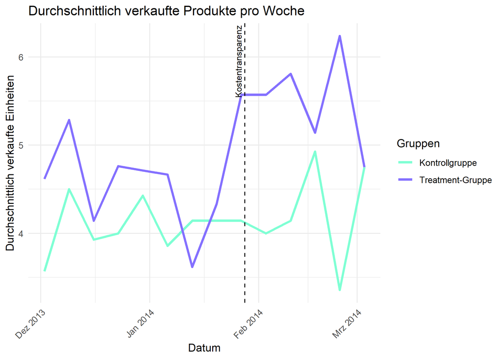

**Beschreibung:**

Die Grafik mit dem Titel „Durchschnittlich verkaufte Produkte pro Woche“ zeigt den Verlauf der durchschnittlich verkauften Einheiten zweier Produktgruppen über einen Zeitraum von Dezember 2013 bis März 2014. Auf der x-Achse sind die Wochen in monatlichen Schritten dargestellt, beginnend mit „Dez2013“ und endend mit „Mrz2014“. Die y-Achse zeigt die durchschnittlich verkauften Einheiten, wobei die Skala Werte von etwa 4 bis 6 explizit anzeigt, jedoch auch leicht darüber und darunter hinausgeht.

Es sind zwei Linien dargestellt: Die Treatment-Gruppe ist in lightslateblue eingezeichnet, die Kontrollgruppe in aquamarine. Beide Gruppen sind in einer mittig rechts platzierten Legende mit der Überschrift „Gruppen“ eindeutig bezeichnet. Eine vertikale gestrichelte Linie markiert den 28. Januar 2014 – das Datum der Einführung der Kostentransparenzmaßnahme. Direkt an dieser Linie befindet sich die Beschriftung „Kostentransparenz“, die ihre Bedeutung deutlich macht.

Der Verlauf der Linie der Treatment-Gruppe zeigt eine dynamische Entwicklung: Beginnend bei etwa 4,6 durchschnittlich verkauften Einheiten, steigt sie zunächst auf rund 5,3 an, fällt dann deutlich auf ca. 4,2, erholt sich leicht, sinkt wieder und steigt schließlich stark an – bis kurz vor dem Einführungsdatum der Kostentransparenz. In den Wochen nach der Einführung ist zunächst eine leichte Stabilisierung zu beobachten, danach folgen mehrere starke Bewegungen: ein erneuter Anstieg, ein deutlicher Rückgang und ein anschließender starker Aufschwung, gefolgt von einem noch stärkeren Rückgang.

Am Ende der Grafik nähern sich beide Linien stark an und schneiden sich im letzten dargestellten Punkt exakt. Bereits in den letzten Wochen vor dem Ende der Zeitreihe verlaufen die Linien phasenweise spiegelbildlich zueinander, was auf eine mögliche Reaktion der Gruppen auf die Maßnahme hindeutet.

**Interpretation:**

Nach dem 28. Januar 2014 zeigen sich systematische Unterschiede zwischen den beiden Gruppen: Es scheint, als ob sich die Entwicklung der Verkaufszahlen nach der Einführung der Kostentransparenz teilweise gegensätzlich vollzieht. Insbesondere fällt auf, dass in mehreren Zeitabschnitten jeweils ein Anstieg in der einen Gruppe mit einem Rückgang in der anderen Gruppe einhergeht – ein Muster, das sich wiederholt. Diese gegenläufigen Bewegungen nach der Intervention deuten auf eine mögliche Wirkung der Maßnahme hin.

Angenommen, beide Gruppen zeigen vor dem Eingriff tatsächlich einen gleich starken Trend, würde das bedeuten, dass die Voraussetzung für eine valide kausale Interpretation im DiD-Rahmen gegeben ist. Ein beobachteter Unterschied in der Entwicklung nach der Maßnahme könnte dann mit hoher Wahrscheinlichkeit auf die Kostentransparenzmaßnahme zurückgeführt werden. Die Grafik liefert somit erste visuelle Hinweise darauf, dass die Maßnahme einen Einfluss auf die Verkaufszahlen gehabt haben könnte – eine Hypothese, die im nächsten Schritt durch eine formale DiD-Regression überprüft werden sollte.

21. Erstellen Sie eine (mehrere) weitere passende Grafik(en), die die durchschnittlich verkauften Einheiten pro Tag in Treatment und Kontrolle vor und nach der Einführung der Kostentransparenz abbildet. Ergänzen Sie in ihrer Grafik die jeweiligen Standardfehler als Fehlerbalken. Beschreiben und interpretieren Sie ihre Grafik. Gehen Sie insbesondere auf die Unterschiede vor und nach der Einführung der Kostentransparenz ein.
- Inwiefern lassen sich daraus erste Hinweise auf einen möglichen Effekt des natürlichen Experiments erkennen?

*Hinweis:* Für die Erstellung der Grafik können Sie sich an Aufgabe 7 und 9 orientieren.

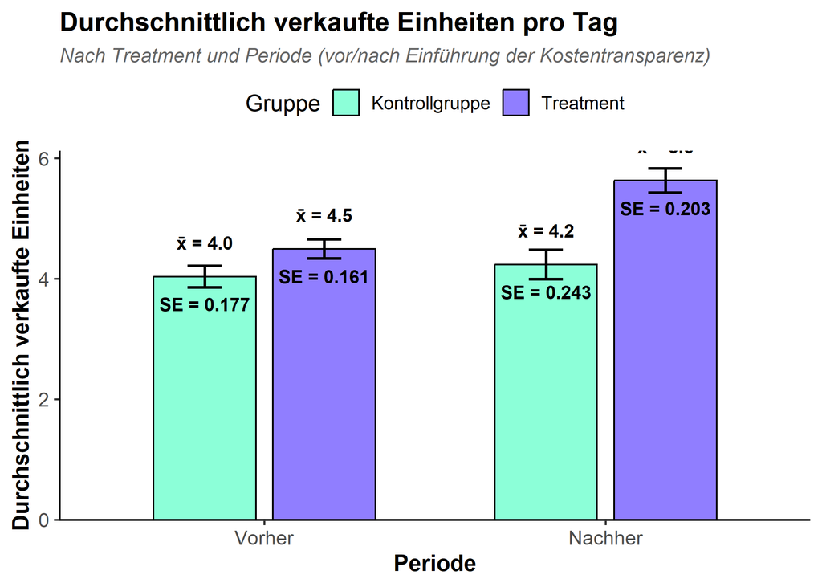

**Beschreibung:**

Die Grafik trägt den Titel „Durchschnittlich verkaufte Einheiten pro Tag“ und stellt die Verkaufszahlen getrennt nach Treatment- und Kontrollgruppe vor sowie nach der Einführung der Kostentransparenz dar. Auf der x-Achse sind die beiden Zeiträume „vorher“ und „nachher“ abgebildet, welche die Phasen vor und nach der Maßnahme kennzeichnen. Die y-Achse zeigt die durchschnittlich verkauften Einheiten pro Tag auf einer Skala von null bis sechs. Für jeden Zeitraum sind jeweils zwei Balken dargestellt, die die Mittelwerte der Kontrollgruppe und der Treatment-Gruppe repräsentieren. Die Kontrollgruppe ist in Aquamarine, die Treatment-Gruppe in Lightslateblue dargestellt, wodurch eine klare Unterscheidung ermöglicht wird. Über jedem Balken sind Fehlerbalken eingefügt, die den Standardfehler der Mittelwerte visualisieren. Zusätzlich sind die exakten Werte der Mittelwerte sowie der Standardfehler neben den Balken abgebildet, sodass ein präziser Vergleich möglich ist.

**Interpretation:**

Die Grafik verdeutlicht, dass vor der Einführung der Kostentransparenz die durchschnittlichen Verkaufszahlen zwischen Kontroll- und Treatment-Gruppe vergleichbar und relativ stabil waren. Nach der Maßnahme zeigt sich jedoch ein deutlicher Unterschied: Die Kontrollgruppe in Aquamarine verzeichnet lediglich einen moderaten Anstieg, während die Treatment-Gruppe in Lightslateblue einen signifikanten Anstieg der Verkaufszahlen aufweist. Die Fehlerbalken überlappen nicht, was auf eine statistisch bedeutsame Differenz schließen lässt.

Diese Beobachtungen deuten auf einen positiven Effekt der Kostentransparenz auf die Verkaufszahlen der Treatment-Gruppe hin. Da die Kontrollgruppe als Referenzgruppe dient und kaum Veränderungen zeigt, kann ein genereller Einfluss externer Faktoren als Ursache für den Anstieg in der Treatment-Gruppe weitgehend ausgeschlossen werden. Die deutlich unterschiedliche Entwicklung in den beiden Gruppen spricht somit für eine ursächliche Wirkung der Kostentransparenz. Die Grafik liefert damit erste überzeugende visuelle Hinweise auf den Effekt des natürlichen Experiments. Für eine fundierte Bewertung sollte dies im Rahmen weiterführender statistischer Methoden, wie beispielsweise einem Difference-in-Differences-Ansatz, vertieft untersucht werden.

22. In der vorherigen Aufgabe haben Sie den Effekt von Kostentransparenz auf die Verkaufszahlen anhand eines deskriptiven Vergleichs untersucht. Dabei haben Sie die durchschnittlich täglich verkauften Einheiten je Treatment vor und nach der Einführung der Transparenzmaßnahme grafisch gegenübergestellt. In dieser Aufgabe sollen Sie diesen Effekt nun ökonometrisch genauer untersuchen, indem Sie den Difference-in-Differences Ansatz in einem Regressionsrahmen anwenden.

Untersuchen Sie den Effekt der Einführung von Kostentransparenz auf die Verkaufszahlen mithilfe einer Difference-in-Differences Regression. Verwenden Sie hierfür Beobachtungen an Werktagen, sowie am Wochenende (Montag bis Sonntag), mit positiven Verkaufszahlen.

Erstellen Sie insgesamt zwei Regressionsmodelle:

- Basismodell ohne Kontrollvariablen
- Modell mit Kontrolle für Wochentagseffekte

Stellen Sie die Ergebnisse anschaulich dar. Beschreiben und interpretieren Sie Ihre Ergebnisse. Gehen Sie insbesondere auf folgende Aspekte ein.

- Wie würden Sie die Größe des Effekts interpretieren, den Sie für `treated:post` erhalten haben?
- Welche Vorteile bringt es, log_units (logarithmierte Verkäufe) als abhängige Variable zu verwenden?
- Können Sie aus Ihrer Schätzung auf einen kausalen Effekt der Kostentransparenz schließen?
- Inwiefern hilft die Kontrolle für Wochentage dabei, Verzerrungen in der Schätzung zu vermeiden?
- Würden Sie auf Basis Ihrer Analyse eine Empfehlung zur Beibehaltung oder Ausweitung der Kostentransparenz geben?
- Worin könnten ihrer Ansicht nach Probleme liegen bei der Betrachtung eines natürlichen Experiments, die die Ergebnisse verzerren könnten?

*Hinweis 1:* Nutzen Sie für die Schätzung die `feols()`-Funktion aus dem fixest-Paket.

*Hinweis 2:* Nutzen Sie die logarithmierten täglichen Verkaufszahlen als abhängige Variable.

**Regressionsergebnisse: Einfluss von Kostentransparenz auf log(Verkäufe)**

**Abhängige Variable: Logarithmierte Verkaufszahlen (log_units)**

|  | Ohne Wochentage | Mit Wochentagen |
| --- | --- | --- |
| Log. Verkaufszahlen (Konstante) | 1.604 [1.564, 1.645]*** | 1.602 [1.508, 1.696]*** |
| Kostentransparenz (Treatment) | 0.229 [0.146, 0.311]*** | 0.228 [0.146, 0.310]*** |
| Dienstag |  | 0.019 [-0.110, 0.149] |
| Mittwoch |  | 0.100 [-0.030, 0.229] |
| Donnerstag |  | -0.060 [-0.190, 0.070] |
| Freitag |  | 0.036 [-0.096, 0.168] |
| Samstag |  | 0.008 [-0.125, 0.140] |
| Sonntag |  | -0.088 [-0.220, 0.045] |
| R² | 0.06 | 0.08 |
| Adj. R² | 0.058 | 0.067 |
| AIC | 448.47 | 450.08 |
| BIC | 456.78 | 483.31 |
| Beobachtungen | 470 | 470 |

Signifikanz: *** p < 0.001, ** p < 0.01, * p < 0.05

**Beschreibung:** Die Tabelle präsentiert die Ergebnisse einer Difference-in-Differences Regression, die den Einfluss der Kostentransparenz auf die Verkaufszahlen untersucht. Dabei wurden zwei Modelle geschätzt: eines ohne Berücksichtigung von Wochentagseffekten und eines mit deren Kontrolle.

Die Ergebnisse für einzelne Wochentage zeigen leichte Unterschiede in den Verkaufszahlen, wobei Mittwoch einen positiven Effekt hat (+0.100), während Sonntag einen leicht negativen Einfluss aufweist (-0.088). Die statistische Signifikanz dieser Wochentagseffekte ist jedoch begrenzt. Weitere Modellgütemaße wie AIC und BIC zeigen, dass das Basismodell etwas effizienter ist, allerdings erlaubt das Modell mit Wochentagseffekten eine detailliertere Betrachtung möglicher Einflussfaktoren.

Zusammenfassend deuten die Ergebnisse darauf hin, dass die Einführung von Kostentransparenz die Verkaufszahlen signifikant erhöht. Die Kontrolle für Wochentage verbessert die Schätzung leicht, indem mögliche systematische Schwankungen berücksichtigt werden. Um kausale Rückschlüsse mit noch größerer Sicherheit zu ziehen, könnte eine weiterführende Analyse notwendig sein, beispielsweise durch robuste Placebo-Tests oder zusätzliche Kontrollvariablen.

**Interpretation:**

**Wie würden Sie die Größe des Effekts interpretieren, den Sie für treated:post erhalten haben?**

In der vorliegenden Regressionstabelle ist der DiD-Effekt als “Kostentransparenz (Treatment)” ausgewiesen. Für beide Modelle (ohne und mit Wochentagen) beträgt der Koeffizient ca. 0.229 bzw. 0.228 und ist hoch statistisch signifikant (p < 0.001, gekennzeichnet durch ***).

Da die abhängige Variable die logarithmierten Verkaufszahlen (log_units) sind, wird der Koeffizient als prozentuale Änderung interpretiert. Dies bedeutet, dass die Einführung der Kostentransparenz zu einer Steigerung der täglichen Verkaufszahlen um etwa 25.7% in der Behandlungsgruppe geführt hat, im Vergleich zur Kontrollgruppe im selben Zeitraum. Der Effekt ist robust, da er sowohl im Modell ohne als auch im Modell mit Wochentagseffekten ähnlich groß und hochsignifikant ist.

**Welche Vorteile bringt es, log_units (logarithmierte Verkäufe) als abhängige Variable zu verwenden?**

Die Verwendung von logarithmierten Verkaufszahlen (log_units) als abhängige Variable hat mehrere Vorteile in ökonometrischen Analysen:

**Interpretation als prozentuale Effekte:** Wie oben erläutert, können die Regressionskoeffizienten direkt als prozentuale Veränderungen interpretiert werden. Dies ist oft intuitiver und relevanter, da es die relative Größe von Effekten unabhängig von der absoluten Verkaufsmenge ausdrückt (z.B. 10% Anstieg ist bei 100 Einheiten wie bei 1000 Einheiten ein 10% Anstieg).

**Normalisierung der Verteilung:** Verkaufsdaten sind oft rechtsschief verteilt und können Ausreißer enthalten. Die Logarithmierung hilft, die Verteilung der Daten symmetrischer und näher an eine Normalverteilung zu bringen, was für die Annahmen der linearen Regression vorteilhaft ist (z.B. für die Annahme normalverteilter Residuen).

**Reduzierung von Heteroskedastizität:** Häufig nimmt die Varianz der Verkaufszahlen mit dem Niveau der Verkaufszahlen zu (Heteroskedastizität). Die Logarithmierung kann dazu beitragen, diese Varianz proportionaler zu gestalten (Homoskedastizität), was die Effizienz der Schätzer verbessert und die Gültigkeit der Standardfehler sicherstellt.

**Umgang mit nicht-negativen Werten:** Verkaufszahlen sind naturgemäß nicht-negativ. Die Logarithmierung stellt sicher, dass die vorhergesagten Werte ebenfalls positiv sind, da e^x immer positiv ist.

**Können Sie aus Ihrer Schätzung auf einen kausalen Effekt der Kostentransparenz schließen?**

Der Difference-in-Differences (DiD) Ansatz ist ein leistungsfähiges quasi-experimentelles Design, das darauf abzielt, kausale Effekte zu identifizieren. Der Schlüssel zur kausalen Interpretation liegt in der Parallel-Trends-Annahme. Diese Annahme besagt, dass sich die logarithmierten Verkaufszahlen der Behandlungs- und Kontrollgruppe in Abwesenheit der Intervention (Kostentransparenz) parallel entwickelt hätten.

Wenn diese Annahme erfüllt ist und keine anderen unkontrollierten Faktoren die Ergebnisse verzerren (z.B. andere gleichzeitige, gruppenspezifische Schocks oder Ereignisse), dann kann man aus der Schätzung von treated:post (Kostentransparenz (Treatment)) auf einen kausalen Effekt schließen.

Die vorliegenden Ergebnisse zeigen einen signifikanten Effekt. Um die Kausalität weiter zu stärken, müsste die Parallel-Trends-Annahme empirisch plausibilisiert werden, z.B. durch:

-Visuelle Inspektion der Trends in der Vor-Interventionsperiode.

-Hinzufügen von Interaktionstermen zwischen der Behandlungsgruppe und Zeit-Dummies in der Vorperiode (Event-Study-Design); hier sollte keiner dieser Koeffizienten signifikant sein.

-Kontrolle für weitere zeitlich variierende, gruppenspezifische Kovariaten.

Ohne diese zusätzlichen Checks ist ein DiD-Ergebnis ein starker Hinweis auf Kausalität, aber die Annahme muss immer sorgfältig geprüft werden.

**Inwiefern hilft die Kontrolle für Wochentage dabei, Verzerrungen in der Schätzung zu vermeiden?**

Die Kontrolle für Wochentagseffekte (wie im Modell “Mit Wochentagen” geschehen) hilft auf folgende Weisen, Verzerrungen zu vermeiden und die Präzision der Schätzung zu erhöhen:

**Erfassung systematischer wöchentlicher Variationen:** Verkaufszahlen unterliegen oft starken wochentäglichen Mustern (z.B. höhere Verkäufe am Wochenende oder bestimmten Wochentagen). Wenn die Zusammensetzung der Tage in der Beobachtungsperiode (vor/nach) oder zwischen den Gruppen (Behandlung/Kontrolle) nicht gleichmäßig ist, könnten diese wöchentlichen Schwankungen fälschlicherweise dem DiD-Effekt zugeschrieben werden. Durch die Kontrolle für Wochentage werden diese systematischen Variationen aus den Residuen entfernt.

**Stärkung der Parallel-Trends-Annahme:** Wenn die wöchentlichen Muster in beiden Gruppen nicht perfekt synchron verlaufen würden oder wenn die Einführung der Intervention zu einem Zeitpunkt erfolgte, der zu einer asymmetrischen Verteilung von Wochentagen vor und nach der Intervention führte, könnten die Wochentagseffekte die beobachteten Trends verzerren. Durch die explizite Modellierung dieser Effekte wird die Annahme, dass die “bereinigten” Trends parallel verlaufen, plausibler.

**Reduzierung der Fehlervarianz:** Die Wochentagseffekte erklären einen Teil der Variation in den Verkaufszahlen. Indem diese Varianz im Modell berücksichtigt wird, wird die unerklärte Varianz (Fehlervarianz) reduziert. Eine geringere Fehlervarianz führt zu kleineren Standardfehlern der geschätzten Koeffizienten, was die Schätzungen präziser macht und die statistische Signifikanz erhöht, falls ein tatsächlicher Effekt vorhanden ist. Im vorliegenden Fall sehen wir, dass der R^2 -Wert von 0.06 auf 0.08 ansteigt, wenn Wochentagseffekte hinzugefügt werden, was bedeutet, dass ein zusätzlicher Teil der Varianz durch die Wochentage erklärt wird.

**Würden Sie auf Basis Ihrer Analyse eine Empfehlung zur Beibehaltung oder Ausweitung der Kostentransparenz geben?**

Basierend auf den vorliegenden Regressionsergebnissen würde ich eine Empfehlung zur Beibehaltung und potenziellen Ausweitung der Kostentransparenz geben.

Der Koeffizient für “Kostentransparenz (Treatment)” (der DiD-Effekt) ist in beiden Modellen hoch statistisch signifikant und positiv (0.229 bzw. 0.228). Dies deutet darauf hin, dass die Einführung der Kostentransparenz zu einer robusten und substanziellen Steigerung der Verkaufszahlen um etwa 25.7% geführt hat. Dieser Effekt bleibt bestehen, auch nachdem für potenzielle Wochentagseffekte kontrolliert wurde, was die Robustheit der Schätzung unterstreicht.

Bevor jedoch eine endgültige und weitreichende Empfehlung getroffen wird, sollten folgende Aspekte berücksichtigt werden:

**Parallel-Trends-Annahme:** Die Gültigkeit dieser zentralen Annahme müsste noch genauer geprüft werden, z.B. durch eine visuelle Inspektion der Verkaufsentwicklung vor der Intervention oder formale Tests.

**Kosten-Nutzen-Analyse:** Die positiven Effekte auf die Verkaufszahlen müssten den Kosten der Implementierung und Aufrechterhaltung der Kostentransparenz gegenübergestellt werden.

**Andere Effekte:** Hat die Kostentransparenz auch andere gewünschte Effekte (z.B. Kundenzufriedenheit, Vertrauen) oder unerwünschte Nebeneffekte (z.B. höhere Betriebskosten, Komplexität)?

Unter der Annahme, dass die Parallel-Trends-Annahme plausibel ist und die Kosten vertretbar sind, sprechen die Ergebnisse stark für den Nutzen der Kostentransparenz.

**Worin könnten ihrer Ansicht nach Probleme liegen bei der Betrachtung eines natürlichen Experiments, die die Ergebnisse verzerren könnten?**

Obwohl natürliche Experimente wie der DiD-Ansatz wertvoll sind, um kausale Effekte zu identifizieren, sind sie nicht ohne potenzielle Probleme und Einschränkungen, die die Ergebnisse verzerren könnten:

**Verletzung der Parallel-Trends-Annahme:** Dies ist das kritischste Problem. Wenn sich die Trends der Verkaufszahlen in der Behandlungs- und Kontrollgruppe ohne die Intervention ohnehin unterschiedlich entwickelt hätten, ist der DiD-Schätzer verzerrt. Dies könnte passieren, wenn beispielsweise ein anderes, nicht beobachtetes Ereignis gleichzeitig mit der Einführung der Kostentransparenz auftrat und nur die Behandlungsgruppe beeinflusste.

**Selektionseffekte (unbeobachtete Heterogenität):** Obwohl DiD für zeitlich konstante, unbeobachtete Unterschiede zwischen Gruppen kontrolliert, könnten andere unbeobachtete Variablen, die sich im Zeitverlauf ändern und sowohl die Zuweisung zur Behandlungsgruppe als auch die Verkaufszahlen beeinflussen, zu Verzerrungen führen.

**Spillover-Effekte (Übertragungseffekte):** Wenn die Einführung der Kostentransparenz in der Behandlungsgruppe indirekte Auswirkungen auf die Kontrollgruppe hat (z.B. Kunden der Kontrollgruppe erfahren von der Transparenz und wechseln zur Behandlungsgruppe, oder die Konkurrenz in der Kontrollgruppe reagiert auf die Transparenzmaßnahmen), wird der Effekt der Behandlungsgruppe möglicherweise unter- oder überschätzt.

**Messfehler:** Ungenaue oder inkonsistente Messung der abhängigen Variable (Verkaufszahlen) oder der Behandlung (Kostentransparenz) kann zu Attenuierung (Unterschätzung des Effekts) oder Bias führen.

# Literatur

Mohan, B., Buell, R. W., & John, L. K. (2020). Lifting the veil: The benefits of cost transparency. Marketing Science, 39(6), 1105-1121. https://doi.org/10.1287/mksc.2019.1200

# Anhang

## Mediator

Im Rahmen von Mediationen ist der Mediator eine Variable, die den erklärenden Zusammenhang zwischen einer unabhängigen und einer abhängigen Variable vermittelt. Dabei wird untersucht, inwieweit der Einfluss der unabhängigen Variablen (z.B. Kostentransparenz) auf die abhängige Variable (z.B. Kaufabsicht) über einen vermittelnden Mechanismus - wie das Vertrauen der Kunden - erfolgt.

1. **Mediatoreffekt**: Der Mediatoren-Effekt, oft als ACME (Average Causal Mediation Effect) bezeichnet, beschreibt den indirekten Effekt, den die unabhängige Variable auf die abhängige Variable über den Mediator ausübt. Ist dieser Effekt signifikant, signalisiert dies, dass ein wesentlicher Teil des gesamten Einflusses über den vermittelnden Mechanismus läuft. Gleichzeitig kann ein nicht-signifikanter direkter Effekt (ADE - Average Direct Effect) darauf hindeuten, dass der Mediator den hauptsächlichen Erklärungsmechanismus darstellt.
2. **Funktion und Wirkung des Mediators**: Analog zum Konzept der signalgebenden Funktion bei Statussymbolen - deren Wert unter anderem von der Exklusivität und dem sozialen Kontext abhängt - fungiert der Mediator als vermittelnder Kanal, der erklärt, wie und warum der ursprüngliche Zusammenhang zwischen zwei Variablen zustande kommt. Der Mediator „überträgt“ quasi den Effekt der unabhängigen Variable auf die abhängige Variable. Dadurch kann in Modellen, in denen der direkte Zusammenhang zwischen der unabhängigen und der abhängigen Variable durch die Einbeziehung des Mediators verschwindet oder abgeschwächt wird, abgeleitet werden, dass der Mechanismus über den Mediator läuft. Dies ermöglicht ein tieferes Verständnis der zugrundeliegenden psychologischen Prozesse - etwa wie das Vertrauen der Kunden die Wirkung von Kostentransparenz auf deren Kaufabsicht vermittelt.

Zusammengefasst spielt der Mediator eine zentrale Rolle bei der Aufklärung der kausalen Mechanismen, indem er als vermittelnder Faktor zwischen Ursache und Wirkung identifiziert wird. Die signifikante Vermittlung über den Mediator zeigt, dass nicht allein das Vorhandensein von Kostentransparenz entscheidend ist, sondern auch, inwiefern diese Transparenz das Vertrauen stärkt - was wiederum maßgeblich die Kaufabsicht beeinflusst. So liefert die Mediationsanalyse wertvolle Einsichten, die über einfache bivariate Zusammenhänge hinausgehen und die Komplexität kausaler Mechanismen innerhalb von sozialen oder marktorientierten Prozessen sichtbar machen.